Agrupamentos dos Estabelecimentos de Internação registrados no TABNET, São Paulo, entre 2020 e 2022, de acordo com a evolução da Covid19 Síndrome Respiratória Aguda Grave **Prevent Senior** *Sistema de Gestão da Qualidade* Última atualização em 24 / 10 / 2022 às 09:28 horas.

Abstract

Este relatório agrupa os estabelecimentos de internação para covid-19 (Síndrome Respiratória Aguda Grave) registrados no TABNET, Secretaria Municipal de Saúde de São Paulo, em grupos homogêneos em função do grau de similaridade entre si, a partir das variáveis **total de internados**, **cura**, **óbito** e **taxa de óbito** (evolução dos pacientes internados).

# Introdução

O impacto global da Síndrome Respiratória Aguda Grave (SRAG) é difícil de estimar: fatores demográficos, culturais, econômicos e de saúde, diferenças nos sistemas de saúde entre os diversos países podem explicar algumas diferenças na sua incidência (VILLAR; BLANCO; KACMAREK, 2016).

A mortalidade geral por SRAG aproxima-se de 40-50% em todas as grandes séries descritas na literatura, embora vários estudos randomizados controlados relataram uma melhora na sobrevida em pacientes selecionados com SRAG (VILLAR; SULEMANJI; KACMAREK, 2014). A mortalidade hospitalar por SRAG moderada e grave ainda é superior a 40% (VILLAR; BLANCO; KACMAREK, 2016).

Este relatório tem por objetivo agrupar os estabelecimentos de internação registrados na Secretaria Municipal de Sáude de São Paulo em relação à evolução dos pacientes no que diz respeito à Covid-19 com diagnóstico de SRAG, no período entre março de 2020 e setembro de 2022. Ou seja, segmentar os indivíduos (**estabelecimentos de internação**) com base nas características da evolução dos pacientes internados em suas dependências (**total de internados, número de óbitos, número de curados, taxa de óbitos**).

# Análise de agrupamentos

A análise de agrupamentos ou *clustering* é uma técnica cujo interesse é explorar informações em um conjunto de variáveis em análise. Os métodos de análise de agrupamento são **procedimentos estatísticos**, uma vez que a inclusão de novas variáveis ou de novos indivíduos pode modificar a formação dos *clusters* . Isto requer, obrigatoriamente, a elaboração de nova análise (FÁVERO; BELFIORE, 2017).

O principal objetivo desta técnica é agrupar os indivíduos em *clusters*, de tal forma que:

- Indivíduos de um mesmo *cluster* sejam semelhantes (**similares**) em relação aos valores das variáveis em análise.
- E em contrapartida, os indivíduos de *clusters* distintos sejam diferentes (**dissimilares**).

À guiza de exemplo:

> Segmentar os estabelecimentos de internação cadastrados no TABNET (Secretaria Municipal de Saúde de São Paulo) considerando a evolução dos pacientes internados em suas dependências (**total de internados, número de óbitos, número de curados, taxa de óbitos**) devido à Síndrome Respiratória Aguda Grave no período entre março de 2020 e setembro de 2022.

Trata-se de uma técnica **exploratória**, ou de **interdependência**, cujas aplicações não apresentam caráter preditivo para novos indivíduos não presentes na amostra inicial. É necessária a reaplicação da modelagem sempre que houver a inclusão de novos indivíduos no banco de dados. Tanto a inclusão de novos indivíduos, quanto a inclusão de novas variáveis no banco de dados podem criar um rearranjo completo dos indivíduos do grupo (FÁVERO; BELFIORE, 2017).

A análise de agrupamentos tem ampla aplicação em muitos campos do conhecimento. Exemplificando: comportamento do consumidor, segmentação de mercado, política, economia, finanças, contabilidade, atuária, medicina, biologia, bioestatítica, genética, engenharia, ciências da computação, criminologia e perícia, entre outras áreas (FÁVERO; BELFIORE, 2017).

## Boas práticas para a criação de agrupamentos

Os algortimos para análise de *clusters* se baseiam em medidas de dissimilaridade. Estas medidas permitem quantificar a diferença entre indivíduos com base nos valores apresentados para o conjunto de variáveis.

A técnica segmenta os indivíduos em grupos homogêneos internamente e heterogêneos entre si e mutuamente exclusivos. A técnica consiste em **ordenar** e **alocar** os indivíduos em **grupos**. Desta forma, é possível verificar como se comportam o ordenamento e a alocação desses indivíduos nos grupos criados, buscando uma estrutura natural para eles. (FÁVERO; BELFIORE, 2017).

### Perspectiva em relação ao analista de dados

#### Contexto com definição clara do propósito

A SRAG foi uma manisfetação grave, por vezes letal, da covid-19, em todos os continentes, amplamente divulgado nos meios de comunicação, sejam científicos ou não.

O uso de vacinas para o combate da doença modificou a história natural da covid-19.

Considerando este contexto, esta análise, tem por objetivo explorar informações sobre padrões de agrupamentos dos estabelecimentos de internação registrados no [TABNET](https://www.prefeitura.sp.gov.br/cidade/secretarias/saude/tabnet/) (Secretaria Municipal de Saúde de São Paulo), no período de março de 2020 até setembro de 2022, conforme a evolução dos pacientes internados com o diagnóstico de SRAG em suas dependências.

O propósito desta análise é agrupar os estabelecimentos de internação em *clusters*, de tal forma que:

- Estabelecimentos de internação de um mesmo *cluster* sejam semelhantes (**similares**) em relação aos valores das variáveis em análise (evolução dos pacientes internados em suas dependências).
- E em contrapartida, os estabelecimentos de internação de *clusters* distintos sejam diferentes (**dissimilares**).

#### Variáveis pertinentes para o agrupamento

No menu da página do TABNET, no item, [Síndrome Respiratória Aguda Grave](http://tabnet.saude.prefeitura.sp.gov.br/cgi/deftohtm3.exe?secretarias/saude/TABNET/RSRAG/sragh.def), é possível selecionar os casos de COVID 19 SÍNDROME RESPIRATÓRIA AGUDA GRAVE, considerando diversas variáveis de interesse.

Para esta análise foram seleciondas:

- **linha**: estabelecimento de internação (*indivíduos y<sub>i</sub>*).
- **coluna**: evolução (*variáveis explicativas x<sub>ij</sub>* - óbito, cura, total de internados e taxa de óbito). A taxa de óbito foi calculada pela razão entre o número de óbitos e o total de internados e traduz a taxa de mortalidade por SRAG nestes estabelecimentos.
- **conteúdo**: número de casos.
- **períodos disponíveis**: 2020, 2021, 2022.

**Nota técnica**: esta análise considera os termos **indivíduo**, **objeto**, **elemento** e **observação** como sinôminos. Neste texto, optou-se por usar o termo indivíduo para descrever cada estabelecimento de internação (y<sub>i</sub>).

Ante o exposto:

- Considere o conjunto de indivíduos y<sub>i</sub> para i = {1, …, n}.
- Cada y<sub>i</sub> $\in$ {estabelecimentos de internação no sistema TABNET}.
- Objetivo: descrever o relacionamento de y<sub>i</sub> com um conjunto de variáveis explicativas x<sub>ij</sub> , com j = {1, …, p}.
- Cada x<sub>ij</sub> $\in$ {óbito, cura, total de internados, taxa de óbitos}.

#### Medida de similaridade/dissimilaridade

Algoritmos de análise de agrupamentos se baseiam em **medidas de dissimilaridade**. Estas medidas quantificam a diferença entre os indivíduos y<sub>i</sub> com base nos valores apresentados para o conjunto de variáveis x<sub>ij</sub>.

A dissimilaridade avaliada para um par de indivíduos y<sub>i</sub> e y<sub>i’</sub> pode ser descrita como:

- d<sub>ii’</sub> , com i e i’ $\in$ {1, 2, …, n}.

As medidas de dissimilaridade atendem às propriedades:

- d<sub>ii’</sub> $\geq$ 0, com d<sub>ii’</sub> = 0 se i = i’;
- d<sub>ii’</sub> = d<sub>i’i</sub> para todo i, i’ $\in$ {1, 2, …, n} (simetria);
- d<sub>ii’</sub> $\leq$ d<sub>ik</sub> + d<sub>i’k</sub> , para todo k $\in$ {1, 2, …, n} (desigualdade triangular).

#### Algoritmo oportuno para o contexto

Cada indivíduo y<sub>i</sub> deve ser alocado a um *cluster* k (k $\in$ {1, 2, …, K}) segundo um codificador k = C(y<sub>i</sub>).

O objetivo consiste em identificar um codificador **ótimo**, de tal sorte que seja possível criar, o máximo possível, *clusters* homogêneos internamente e heterogêneos entre si.

Os algoritmos *não hierárquicos* se baseiam em re-alocações sucessivas dos indivíduos y<sub>i</sub> aos *clusters* para criá-los internamente mais homogêneos.

Esta análise fez uso do algoritmo **k-means**. Este se aplica quando as variáveis x<sub>ij</sub> são quantitativas e a dissimilaridade é baseada na distância Euclideana (menor distância entre dois indivíduos no espaço):

$$d_{ii'} = \sum_{j=1}^p \ (x_{ij} -
x_{i'j})^2 = \|x_i - x_{i'}\|^2$$

Neste análise, para remover o **efeito de escala**, a dissimilaridade foi ponderada na etapa de padronização das variáveis x<sub>ij</sub> pelo **Z-escore**: média 0 e variância 1.

### Perspectiva em relação às características dos dados

#### Densidade

Indivíduos similares (y<sub>i</sub>) nas carcaterísticas definidas (x<sub>ij</sub>) que ocupam o mesmo espaço formam um padrão de alta densidade no *cluster* formado.

Medidas de densidades avaliam quão próximos estão os indivíduos dentro do mesmo *cluster*. Uma variação menor dentro do *cluster* indica uma boa densidade, ou seja, um bom agrupamento. Os diferentes índices para avaliar a densidade dos *clusters* são baseados em medidas de distância, como as distâncias médias/medianas entre os indivíduos (KASSAMBARA, 2017).

#### Separação

Entre os *clusters* formados deve haver espaços vazios que separam os indivíduos dissimilares.

Medidas de separação avaliam o quão bem um *cluster* está separado dos demais. Os índices usados como medidas de separação incluem as distâncias entre os centros dos *clusters* e as distâncias mínimas em pares entre indivíduos em diferentes *clusters* (KASSAMBARA, 2017).

## Algoritmo *K-means*

Nesta análise, consideramos o método de **particionamento** para o algoritmo de agrupamento. Um método de particionamento constrói *k clusters*. Isto é, classifica os dados em **k grupos**, que juntos satisfazem os requisitos de uma partição: cada grupo deve conter pelo menos um indivíduo e cada indivíduo deve pertencer a exatamente um grupo (KAUFMAN; ROUSSEEUW, 2009).

Convém enfatizar que **k** é definido pelo pesquisador. O algoritmo construirá uma partição com quantos *clusters* se desejar. Entretanto, nem todos os valores de **k** criam agrupamentos **naturais**. Assim, se recomenda executar o algoritmo várias vezes com diferentes valores de **k** e selecionar aquele **k** para o qual certas características ou gráficos parecem melhores, ou manter o agrupamento que parece dar origem à interpretação mais significativa (KAUFMAN; ROUSSEEUW, 2009).

## Análise das variáveis e dos objetos para formar os *clusters*

A seleção das variáveis x<sub>ij</sub> deve refletir a estrutura inerente que formam os grupos. Cabe ao pesquisador selecionar aquelas que se alinham ao objetivo da pesquisa. Convém minimizar o uso de variáveis não representativas e atentar para a presença de multicolinariedade (pode interferir na ponderação das medidas de similaridade) (FÁVERO; BELFIORE, 2017).

Esta técnica é altamente sensível à inclusão de variáveis com comportamentos atípicos (*outliers*). Convém verificar a existência de *outliers* e considerar mecanismos para minimizar seus impactos (FÁVERO; BELFIORE, 2017).

# Base de dados de 2020

A base de dados para esta análise está disponível no aplicativo [TABNET](https://www.prefeitura.sp.gov.br/cidade/secretarias/saude/tabnet/index.php?p=296871) desenvolvido pelo DATASUS.

A Secretaria Municipal de Sáude de São Paulo disponibiliza o [TABNET](https://www.prefeitura.sp.gov.br/cidade/secretarias/saude/tabnet/index.php?p=296871) para o acesso às bases de dados de população e dos sistemas de informações do SUS.

## Carregando a base de dados

Esta análise traz o número de casos (**contéudo**) por estabelecimento de internação (**linha**) e por evolução (**coluna**) da página [COVID 19 Síndrome Respiratória Aguda Grave (SGAG)](http://tabnet.saude.prefeitura.sp.gov.br/cgi/tabcgi.exe?secretarias/saude/TABNET/RSRAG/sragh.def).

## Visão geral dos dados

Foram selecionados todos os estabelecimentos de internação y<sub>i</sub> que registraram um total de pelo menos 100 casos de SRAG , em 2020, em suas dependências.

```
## Rows: 151
## Columns: 8
## $ estab_inter  <chr> "2077477 HOSP STA MARCELINA SAO PAULO", "2078015 HC DA FM…
## $ cura         <int> 2837, 2410, 1847, 1594, 1438, 1443, 1388, 1415, 1745, 136…
## $ obito        <int> 748, 1058, 545, 545, 752, 613, 611, 546, 115, 536, 51, 64…
## $ obito_outros <dbl> 136, 38, 2, 16, 1, 3, 1, 34, 6, 4, 0, 5, 2, 1, 3, 18, 1, …
## $ ignorado     <dbl> 4, 22, 2, 2, 1, 8, 1, 14, 5, 1, 11, 1, 17, 63, 1, 0, 1, 4…
## $ sem_info     <dbl> 55, 8, 15, 71, 17, 1, 43, 11, 98, 13, 38, 0, 465, 53, 0, …
## $ total        <int> 3780, 3536, 2411, 2228, 2209, 2068, 2044, 2020, 1969, 191…
## $ taxa_ob      <dbl> 0.19788360, 0.29920814, 0.22604728, 0.24461400, 0.3404255…
```

Em 2020, 151 estabelecimentos de internação registrados no TABNET internaram pelo menos 100 pacientes com SRAG em suas dependências.

## Entendimento da base de dados

```
##   rows columns discrete_columns continuous_columns all_missing_columns
## 1  151       8                1                  7                   0
##   total_missing_values complete_rows total_observations memory_usage
## 1                    0           151               1208        25040
```

Observa-se que:

- Todas as variáveis x<sub>ij</sub> são quantitativas (*int* e *dbl*);
- Há 151 estabelecimentos de internação selecionados (y<sub>i</sub>);
- Não há *missing values* nos dados selecionados.

## Tipos de valores e ocorrência de valores ausentes.

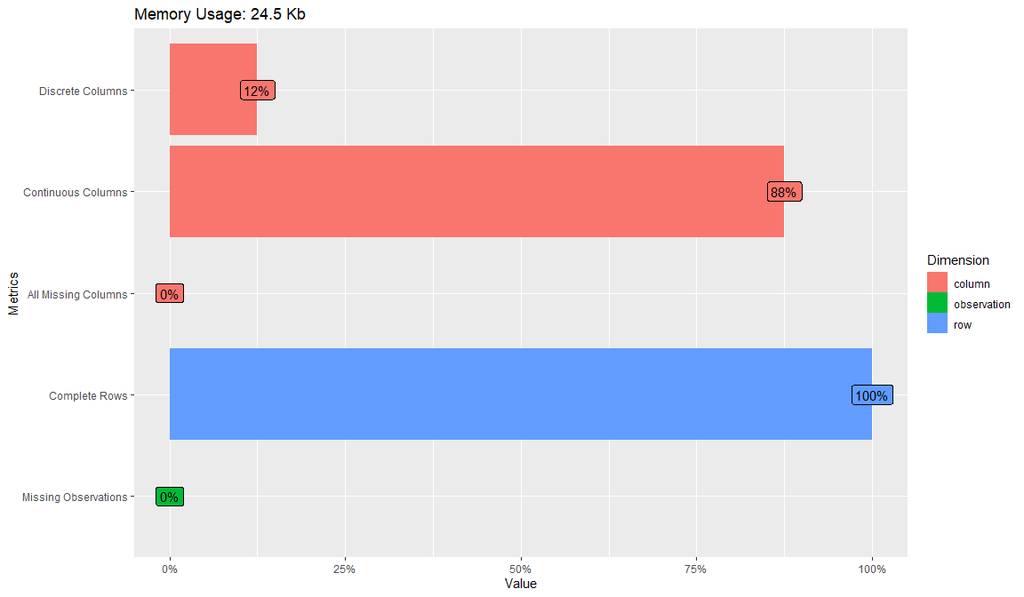

## Perfil dos valores ausentes

## Correlação entre as variáveis

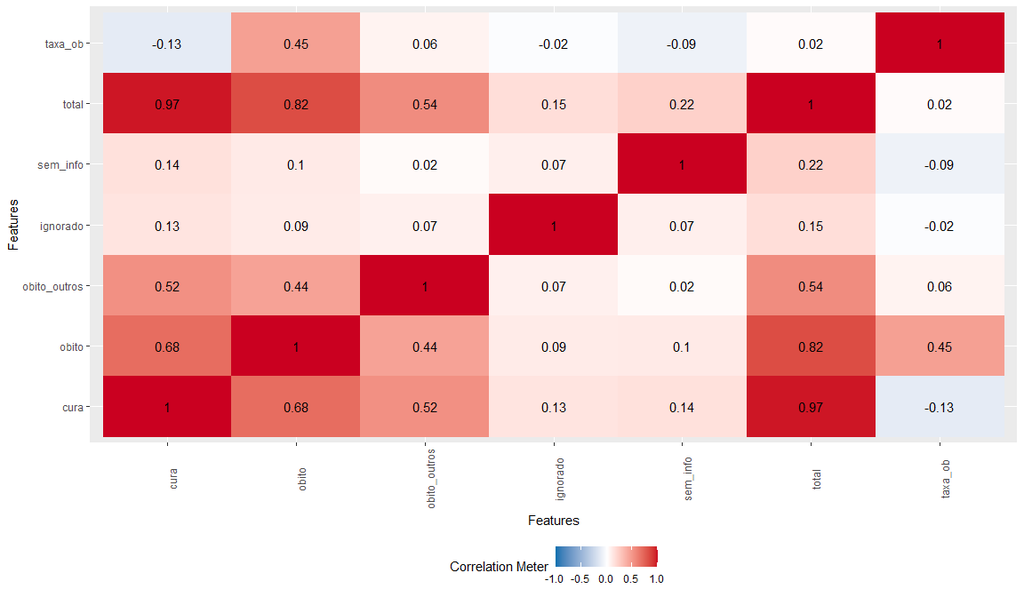

Observa-se uma correlação muito alta entre as variáveis total e cura (0.97) e total e óbito (0.82). No entanto, a variável total foi mantida na análise por absorver as variáveis (sem_info, ignorado, obitos_outros).

## Distribuição das variáveis quantitativas

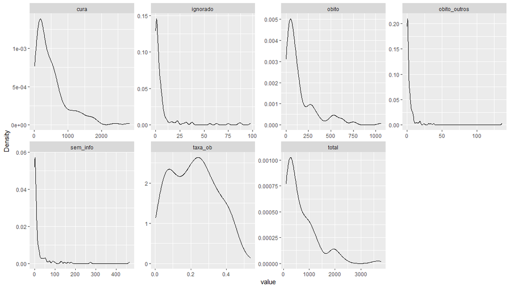

Observa-se forte assimetria positiva (à direita) para todas as variáveis, exceto para a variável taxa de óbito, cujo padrão é bimodal.

# Preparação dos dados

Para fins desta análise foram considerados todos os estabelecimentos de internação com um número igual ou maior a 100 casos de internação/ano. Foram identificados 151 estabelecimentos de internação com esta característica.

No TABNET, no objeto evolução constam cinco variáveis x<sub>ij</sub> : cura, óbito, óbito por outras causas, ignorado e sem informação. As variáveis selecionadas para esta análise foram **cura**, **óbito** e **total de casos**. A variável **taxa de óbito** é a razão entre as variáveis **óbito** e **total de casos**.

As variáveis **óbito por outras causas**, **ignorado** e **sem informação** foram excluídas da análise por serem pouco discriminativas, mas foram absorvidas na variável total de internações.

A próxima saída ilustra os resultados dos seis primeiros estabelecimentos de internação (em ordem decrescente pelo total de casos).

```
##   cura obito total   taxa_ob
## 1 2837   748  3780 0.1978836
## 2 2410  1058  3536 0.2992081
## 3 1847   545  2411 0.2260473
## 4 1594   545  2228 0.2446140
## 5 1438   752  2209 0.3404255
## 6 1443   613  2068 0.2964217
```

## Resumo sumário das variáveis

A próxima saída trás os valores de seis medidas (em ordem crescente):

- **Menor valor** (*Min*): o menor valor da variável registrada em algum estabelecimento de internação.
- **Primeiro quartil Q<sub>1</sub>** (*1st Qu*): 25% dos estabelecimentos de internação registraram uma medida da variável abaixo desse valor.
- **Mediana Q<sub>2</sub>** (*median*): 50% dos estabelecimentos de internação registraram uma medida da variável abaixo desse valor.
- **Média** (*mean*): média aritmética dos valores da variável registrada pelos estabelecimentos de internação.
- **Terceiro quartil Q<sub>3</sub>** (*3rd Qu*): 75% dos estabelecimentos de internação registraram uma medida da variável abaixo desse valor.
- **Maior valor** (*Max*): o maior valor da variável registrada em algum estabelecimento de internação.

```
##       cura            obito            total           taxa_ob
##  Min.   :  11.0   Min.   :   1.0   Min.   : 100.0   Min.   :0.002755
##  1st Qu.: 153.5   1st Qu.:  41.0   1st Qu.: 251.5   1st Qu.:0.102548
##  Median : 368.0   Median :  79.0   Median : 465.0   Median :0.218274
##  Mean   : 514.2   Mean   : 155.7   Mean   : 702.5   Mean   :0.219155
##  3rd Qu.: 659.0   3rd Qu.: 191.5   3rd Qu.: 984.5   3rd Qu.:0.321535
##  Max.   :2837.0   Max.   :1058.0   Max.   :3780.0   Max.   :0.535545
```

À guisa de exemplo, considere a variável **taxa de óbito**:

Nos estabelecimentos de internação selecionados, se verifica que a média da taxa de óbitos por SRAG foi de 21,91% (12.8%).

A linha central marca a mediana do banco de dados. O valor da da mediana foi de 21,82%. Dito de outra maneira, em 2020, 50% dos estabelecimentos de internação da região metropolitana de São Paulo registraram uma taxa de óbito por SRAG inferior a 21.82%.

Em 2020, foram registradas 109.961 casos de COVID 19 SRAG no [TABNET](http://tabnet.saude.prefeitura.sp.gov.br/cgi/tabcgi.exe?secretarias/saude/TABNET/RSRAG/sragh.def), dos quais, 24.581 casos evoluíram para óbito (taxa de óbito = 22.35%)

Observe que 25% dos estabelecimentos de internação registraram uma taxa de óbitos por SRAG igual ou maior a 32.15%.

A taxa máxima de óbito registrada em 2020 foi de 53.53% e não se configura como *outiler*.

Estas informações podem ser visualizadas no seguinte *boxplot*.

### *Boxplot* da taxa de óbitos

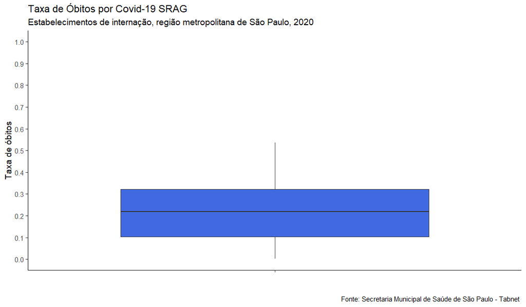

#### Pesquisa de *outliers*

Não se verifica *outliers* na taxa de óbito em 2020.

```
## numeric(0)
```

| estab_inter | total | taxa_ob |
| --- | --- | --- |
| 2091755 HOSPITAL GERAL DE VILA PENTEADO DR JOSE PANGELLA SAO PAULO | 1408 | 0.4453125 |
| 9131434 HOSPITAL SANCTA MAGGIORE HIGIENOPOLIS | 1226 | 0.4331158 |
| 2077639 HOSP MUN PROF DR WALDOMIRO DE PAULA | 1192 | 0.4127517 |
| 2688689 SANTA CASA DE SAO PAULO HOSPITAL CENTRAL SAO PAULO | 1187 | 0.4203875 |
| 7174713 HOSPITAL SANCTA MAGGIORE MOOCA | 779 | 0.4326059 |
| 2091585 HOSPITAL ESTADUAL DE SAPOPEMBA SAO PAULO | 700 | 0.4114286 |
| 2077450 HOSP MUN DR JOSE SOARES HUNGRIA | 693 | 0.4444444 |
| 7676484 HOSPITAL SANTA CLARA | 455 | 0.4043956 |
| 2080788 HOSP MUN V NHOCUNE ALEXANDRE ZAIO | 421 | 0.4085511 |
| 2088495 INSTITUTO DANTE PAZZANESE DE CARDIOLOGIA IDPC SAO PAULO | 329 | 0.4042553 |
| 9997091 UPA JACANA | 294 | 0.4285714 |
| 7711980 HOSP MUN GILSON DE CASSIA MARQUES DE CARVALHO | 278 | 0.4748201 |
| 2075962 HOSP DA STA CASA DE STO AMARO | 255 | 0.4000000 |
| 2080796 HOSP MAT SAO CRISTOVAO | 211 | 0.5355450 |
| 7174691 HOSPITAL SANCTA MAGGIORE ALTO DA MOOCA | 208 | 0.4519231 |
| 2080125 INST DO CANCER ARNALDO VIEIRA DE CARVALHO | 123 | 0.4634146 |
| 7174705 HOSPITAL SANCTA MAGGIORE ITAIM | 119 | 0.4117647 |

Observa-se que 17 estabelecimentos (11.26%) registraram uma taxa de óbito acima de 40% em 2020.

| estab_inter | total | taxa_ob |
| --- | --- | --- |
| 2688603 HOSP STA CATARINA | 1969 | 0.0584053 |
| 0102083 HOSPITAL DE CAMPANHA COVID 19 SMS SP ANHEMBI P 38 | 1898 | 0.0268704 |
| 2089599 HOSP NSRA DE LOURDES | 1834 | 0.0365322 |
| 2688565 HOSPITAL SAO CAMILO POMPEIA | 1769 | 0.0729226 |
| 2089238 HOSP ALVORADA | 1365 | 0.0923077 |
| 5590450 HOSPITAL VILLA LOBOS | 1333 | 0.0465116 |
| 2058391 HOSPITAL ISRAELITA ALBERT EINSTEIN | 1297 | 0.0956052 |
| 2076950 HOSPITAL OSWALDO CRUZ | 1272 | 0.0927673 |
| 3824802 SAO LUIZ UNIDADE MORUMBI | 1170 | 0.0572650 |
| 2089777 HOSPITAL NIPO BRASILEIRO | 1116 | 0.0663082 |
| 6668143 HOSPITAL VITORIA | 1018 | 0.0766208 |
| 2078481 HOSP AVICCENA | 944 | 0.0307203 |
| 2077604 HOSP PRESIDENTE | 737 | 0.0257802 |
| 6283993 HOSPITAL LEFORTE | 671 | 0.0700447 |
| 7992890 HOSPITAL DIA REDE HORA CERTA DA CAPELA DO SOCORRO | 589 | 0.0271647 |
| 2078457 HOSP STA VIRGINIA | 531 | 0.0715631 |
| 0127868 HOSPITAL ESTADUAL DE CAMPANHA COVID 19 IBIRAPUERA | 494 | 0.0263158 |
| 2091801 HOSPITAL CENTRAL DE GUAIANASES | 463 | 0.0734341 |
| 2082314 HOSP ALBERT SABIN | 394 | 0.0862944 |
| 2089610 HOSP EDMUNDO VASCONCELOS | 385 | 0.0649351 |
| 2080168 HOSPITAL DA CRIANCA | 363 | 0.0027548 |
| 2075407 PS MUN V MARIA BAIXA | 358 | 0.0782123 |
| 9735372 HOSPITAL VILA NOVA STAR | 334 | 0.0508982 |
| 2078597 HOSP STA HELENA | 324 | 0.0956790 |
| 0158119 COMPLEXO HOSPITALAR MUNICIPAL SOROCABANA | 283 | 0.0989399 |
| 2078627 DAY HOSPITAL DE ERMELINO MATARAZZO | 274 | 0.0364964 |
| 0102040 HOSPITAL DE CAMPANHA COVID 19 SMS SP PACAEMBU | 265 | 0.0377358 |
| 2688611 HOSP SAO LUIZUNIDADE I | 264 | 0.0871212 |
| 0113123 HOSPITAL DE CAMPANHA COVID 19 SMS SP ANHEMBI P 35 | 257 | 0.0428016 |
| 2078406 HOSP INDEPENDENCIA | 185 | 0.0594595 |
| 9194258 HOSPITAL SAO LUIZ SAO CAETANO | 174 | 0.0287356 |
| 2081628 HOSPITAL CARLOS CHAGAS | 151 | 0.0662252 |
| 2084090 HOSPITAL BARTIRA | 151 | 0.0397351 |
| 2088517 HOSPITAL INFANTIL CANDIDO FONTOURA SAO PAULO | 150 | 0.0200000 |
| 2801051 PRONTO SOCORRO CENTRAL DE DIADEMA | 116 | 0.0775862 |
| 2079186 HOSP MUN MAT ESC DR MARIO DE MORAES A SILVA | 108 | 0.0277778 |
| 7644167 HOSPITAL MORIAH | 101 | 0.0297030 |

Observa-se que 37 estabelecimentos (24.5%) registraram uma taxa de óbito abaixo de 10% em 2020.

### *Boxplot* do número absoluto de pacientes curados

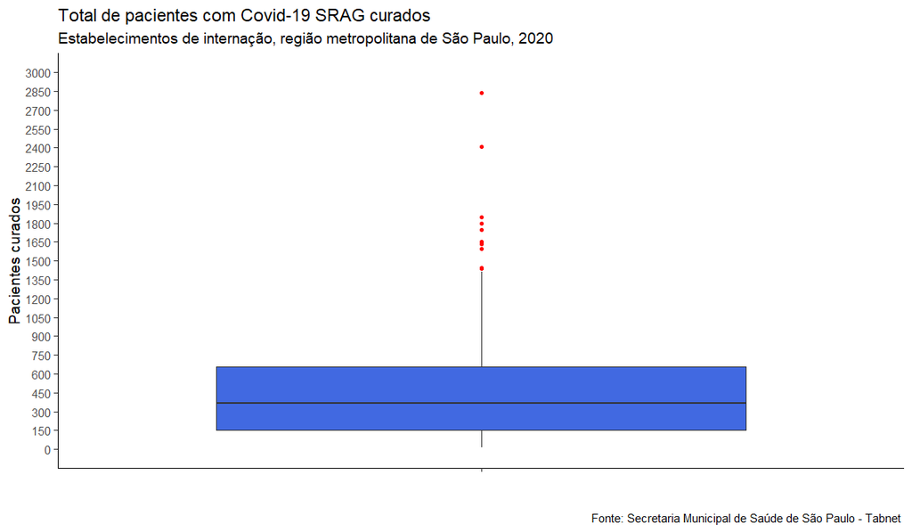

#### Pesquisa de *outliers*

```
##  [1] 2837 2410 1847 1594 1438 1443 1745 1798 1650 1636
```

| estab_inter | cura | taxa_ob |
| --- | --- | --- |
| 2077477 HOSP STA MARCELINA SAO PAULO | 2837 | 0.1978836 |
| 2078015 HC DA FMUSP HOSPITAL DAS CLINICAS SAO PAULO | 2410 | 0.2992081 |
| 9554157 HOSPITAL SALVALUS | 1847 | 0.2260473 |
| 5718368 HOSP MUN M BOI MIRIM | 1594 | 0.2446140 |
| 7174721 HOSPITAL SANCTA MAGGIORE PARAISO | 1438 | 0.3404255 |
| 2058502 HOSP DO SERV PUB EST FCO MORATO DE OLIVEIRA SAO PAULO | 1443 | 0.2964217 |
| 2688603 HOSP STA CATARINA | 1745 | 0.0584053 |
| 0102083 HOSPITAL DE CAMPANHA COVID 19 SMS SP ANHEMBI P 38 | 1798 | 0.0268704 |
| 2089599 HOSP NSRA DE LOURDES | 1650 | 0.0365322 |
| 2688565 HOSPITAL SAO CAMILO POMPEIA | 1636 | 0.0729226 |

Observa-se a presença de 10 estabelecimentos (6.62%) que registraram um número absoluto de pacientes curados acima do padrão geral (*outliers*) em 2020.

### *Boxplot* do número absoluto de óbitos

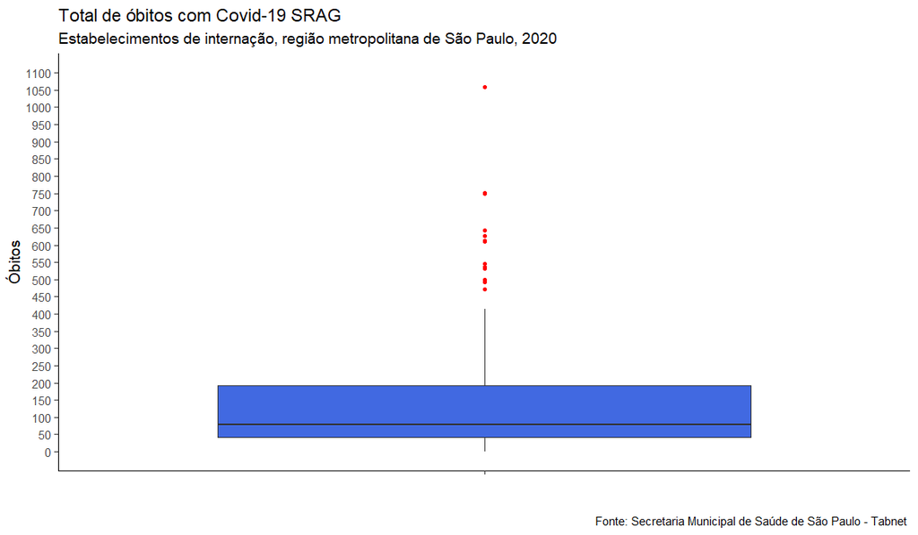

#### Presença de *outliers*

```
##  [1]  748 1058  545  545  752  613  611  546  536  642  471  627  531  492  499
```

| estab_inter | obito | taxa_ob |
| --- | --- | --- |
| 2077477 HOSP STA MARCELINA SAO PAULO | 748 | 0.1978836 |
| 2078015 HC DA FMUSP HOSPITAL DAS CLINICAS SAO PAULO | 1058 | 0.2992081 |
| 9554157 HOSPITAL SALVALUS | 545 | 0.2260473 |
| 5718368 HOSP MUN M BOI MIRIM | 545 | 0.2446140 |
| 7174721 HOSPITAL SANCTA MAGGIORE PARAISO | 752 | 0.3404255 |
| 2058502 HOSP DO SERV PUB EST FCO MORATO DE OLIVEIRA SAO PAULO | 613 | 0.2964217 |
| 2066092 HOSPITAL GERAL DE PEDREIRA | 611 | 0.2989237 |
| 2077485 HOSPITAL SAO PAULO HOSPITAL DE ENSINO DA UNIFESP SAO PAULO | 546 | 0.2702970 |
| 2080583 HOSP MUN TIDE SETUBAL | 536 | 0.2796035 |
| 2077426 HOSPITAL ESTADUAL DE VILA ALPINA ORG SOCIAL SECONCI SAO PAUL | 642 | 0.3422175 |
| 9465464 HOSP MUN JOSANIAS CASTANHA BRAGA | 471 | 0.3277662 |
| 2091755 HOSPITAL GERAL DE VILA PENTEADO DR JOSE PANGELLA SAO PAULO | 627 | 0.4453125 |
| 9131434 HOSPITAL SANCTA MAGGIORE HIGIENOPOLIS | 531 | 0.4331158 |
| 2077639 HOSP MUN PROF DR WALDOMIRO DE PAULA | 492 | 0.4127517 |
| 2688689 SANTA CASA DE SAO PAULO HOSPITAL CENTRAL SAO PAULO | 499 | 0.4203875 |

Observa-se a presença de 15 estabelecimentos (9.93%) que registraram um número absoluto de óbitos acima do padrão geral (*outliers*)em 2020.

### *Boxplot* do total de internações

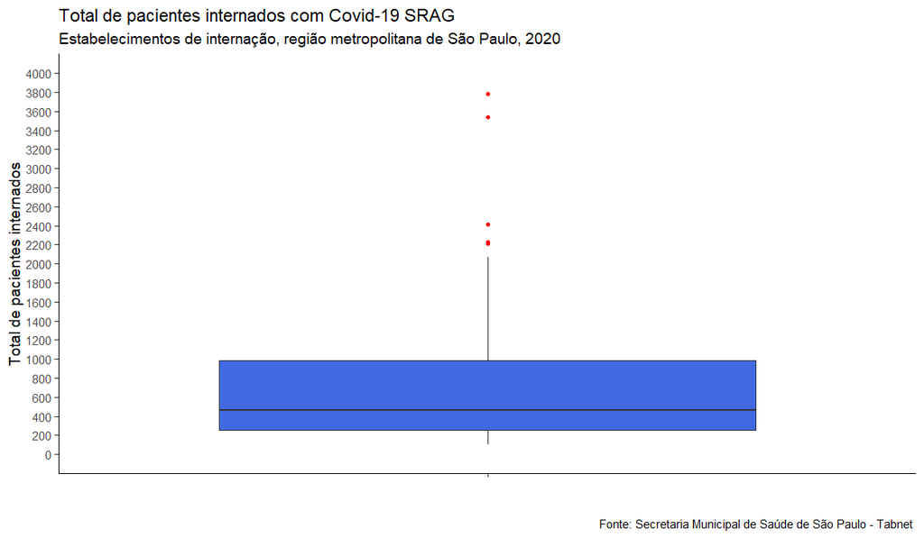

#### Presença de *outliers*

```
## [1] 3780 3536 2411 2228 2209
```

| estab_inter | total | taxa_ob |
| --- | --- | --- |
| 2077477 HOSP STA MARCELINA SAO PAULO | 3780 | 0.1978836 |
| 2078015 HC DA FMUSP HOSPITAL DAS CLINICAS SAO PAULO | 3536 | 0.2992081 |
| 9554157 HOSPITAL SALVALUS | 2411 | 0.2260473 |
| 5718368 HOSP MUN M BOI MIRIM | 2228 | 0.2446140 |
| 7174721 HOSPITAL SANCTA MAGGIORE PARAISO | 2209 | 0.3404255 |

Observa-se a presença de 5 estabelecimentos (3.31%) que registraram um número total de internações acima do padrão geral (*outliers*) em 2020.

## Padronização dos dados 2020

A utilização de variáveis com medidas e ou escalas diferentes podem distorcer a estrutura do *cluster*. Variáveis com maior dispersão têm maior peso para o cálculo das medidas de distância do que as demais.

A padronização dos dados faz com que seja atribuído o mesmo peso para cada variável. Neste estudo foi utilizada a transformação de cada variável em escore padrão (*Z score*). O método Z score padroniza cada variável de modo a apresentar uma média zero(0)e desvio padrão um (1):

$$Z = \frac{(x - média)}{desvio \ padrão}$$

```
##          cura    obito    total     taxa_ob
## [1,] 4.723425 3.228892 4.736602 -0.16622422
## [2,] 3.855131 4.918978 4.361063  0.62556721
## [3,] 2.710285 2.122158 2.629580  0.05385833
## [4,] 2.195816 2.122158 2.347926  0.19894627
## [5,] 1.878594 3.250699 2.318683  0.94765672
## [6,] 1.888761 2.492886 2.101671  0.60379250
```

# Modelagem estatística

> A partir do conceito filosófico de verissimilitude (MEEHL, apud (CHIN, 2010), os modelos perfeitos inexistem e variam no grau em que se assemelham à realidade que se propõem representar. Isto pode ser analisado sob duas perspectivas: a incompletude (*incompleteness*), que trata do quão bem as complexidades do mundo real são representadas pelo modelo, e a inexatidão (*falseness*), que explora como as contradições entre o modelo e o mundo real são adequadamente expressas (CHIN, 2010). Cabe, pois, ao pesquisador, segundo essa concepção, não questionar se o modelo é verídico, mas como ele é autêntico e em que extensão ele se aproxima da realidade (ROZEBOOM, 2005).

> Antonio Sergio da Silva (SILVA, 2014)

## Método *K-means*

O algoritmo *K-means* é o algoritmo de agrupamento particional mais utilizado baseado no critério da soma dos quadrados (KASSAMBARA, 2017; MACQUEEN, 1967). Trata-se de um algoritmo simples, fácil de implementação e implementado em quase todos os *softwares* de mineração de dados. Ademais, é muito versátil, considerando os aspectos inicialização, distância, função, critério de finalização.

À guisa de exemplo, considere uma classificação de imagens de animais. Uma questão importante poderia ser a imagem de um cão. Qualquer imagem que se pareça com um cão ou partes de um cão, será classificado neste *cluster*. Imagens de peixes e aves ficarão distantes desta classificação e aparecerão em outros *clusters*.

## Determinação do número de *clusters*

O método *k-means* é um procedimento não hierárquico para agrupar indivíduos, cujo número inicial de *clusters* é definido pelo pesquisador (FÁVERO; BELFIORE, 2017; KASSAMBARA, 2017).

A análise visual a partir de um gráfico de linhas de duas dimensões: os *K Clusters* (*Number of clusters k*) e a Soma dos Quadrados dos Erros de Predição (*Total Within Sum of Square - SSE*) sugere um número inicial de *clusters* para ser usado. O SSE resulta na variância e desvio padrão (inércia) dos dados da base utilizada. Desta forma pode-se visualizar o valor de quão próximo os dados estão uns dos outros. Quanto menor for o número de *clusters*, maior será o valor dessa inércia (KASSAMBARA, 2017).

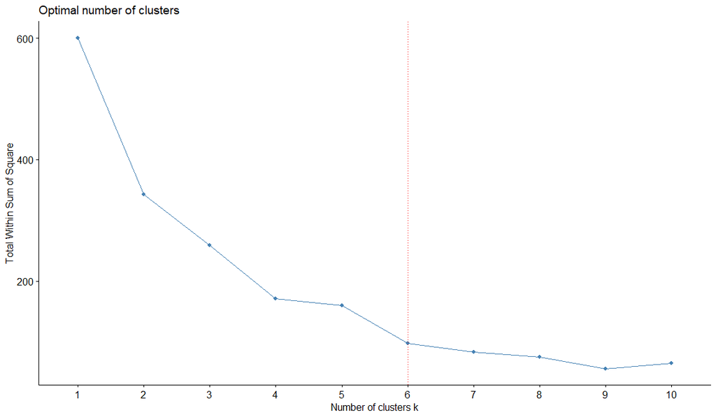

Sendo assim, a quantidade de cinco ou seis *clusters* parece ser um número bem interessante para se aplicar nesse conjunto de dados.

## Visualização gráfica dos *clusters*

O algoritmo para determinar a alocação das observações em cada conglomerado é denominado *nearest centroid sorting*. O *K-means* usa a distância euclidiana como critério de distância para formar os grupos.

A função `fviz_cluster()` do pacote `fatoextra` pode ser usada para visualizar facilmente os *clusters k-means*. No gráfico resultante, as observações são representadas por pontos, usando análise de componentes principais (PCA) quando o número de variáveis x<sub>ij</sub>for maior do que 2 (KASSAMBARA, 2017).

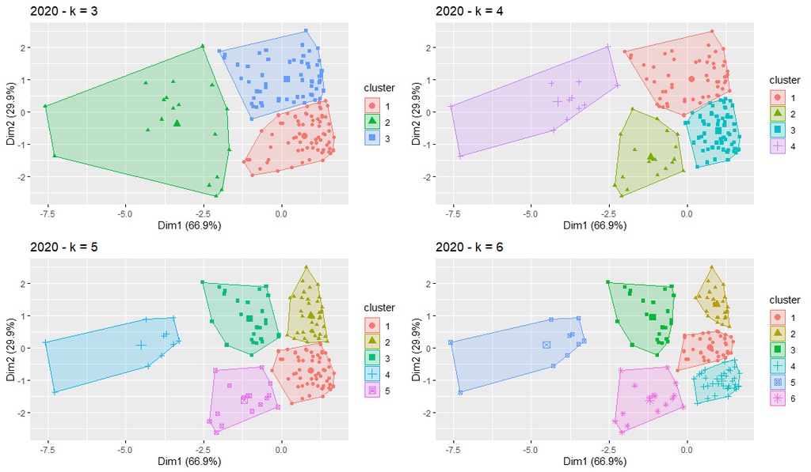

Considerando-se a formação com k = 6 grupos (*clusters*), pode-se perceber que os grupos formados apresentam homogeneidade interna (variabilidade dentro dos grupos), com cada estabelecimento de internação apresentando maior proximidade com outros estabelecimentos do mesmo grupo, do que com estabelecimentos de internação de outros grupos (variabilidade entre os grupos).

## Agrupar *cluster* e base

|  | estab_inter | cura | obito | obito_outros | ignorado | sem_info | total | taxa_ob | evolucao20.k6.cluster |
| --- | --- | --- | --- | --- | --- | --- | --- | --- | --- |
| 46 | 6938876 HOSPITAL E MATERNIDADE INTERMEDICA ABC | 726 | 136 | 13 | 5 | 18 | 898 | 0.1514477 | 1 |
| 51 | 2081970 HOSP MUN JABAQUARA ARTUR RIBEIRO DE SABOYA | 385 | 199 | 0 | 11 | 179 | 774 | 0.2571059 | 1 |
| 52 | 9684948 HOSPITAL SAMARITANO PAULISTA | 534 | 135 | 4 | 6 | 74 | 753 | 0.1792829 | 1 |
| 53 | 2028840 INSTITUTO DE INFECTOLOGIA EMILIO RIBAS SAO PAULO | 569 | 158 | 0 | 22 | 2 | 751 | 0.2103862 | 1 |
| 54 | 3045625 HOSP MAT VIDAS | 600 | 136 | 2 | 0 | 2 | 740 | 0.1837838 | 1 |
| 56 | 2091313 HOSPITAL REGIONAL SUL SAO PAULO | 576 | 157 | 1 | 0 | 2 | 736 | 0.2133152 | 1 |
| 57 | 6146341 UPA PIRITUBA | 489 | 183 | 0 | 32 | 1 | 705 | 0.2595745 | 1 |
| 62 | 2079089 HOSP 9 DE JULHO | 475 | 134 | 7 | 8 | 4 | 628 | 0.2133758 | 1 |
| 64 | 2077493 HOSPITAL GERAL DE SAO MATEUS SAO PAULO | 418 | 155 | 1 | 2 | 14 | 590 | 0.2627119 | 1 |
| 68 | 2082624 HOSP STA CRUZ | 427 | 105 | 0 | 2 | 0 | 534 | 0.1966292 | 1 |
| 70 | 3039420 HOSPITAL SAO CAMILO SANTANA | 421 | 106 | 0 | 3 | 0 | 530 | 0.2000000 | 1 |
| 72 | 2752077 HOSP DO SERV PUB MUNICIPAL HSPM | 360 | 128 | 19 | 2 | 8 | 517 | 0.2475822 | 1 |
| 73 | 2089602 HOSP MAT DO SEPACO | 413 | 91 | 0 | 4 | 2 | 510 | 0.1784314 | 1 |
| 74 | 2078082 HOSPITAL E MATERNIDADE METROPOLITANO | 418 | 84 | 1 | 3 | 0 | 506 | 0.1660079 | 1 |
| 76 | 2084139 HOSP MUN DR BENEDICTO MONTENEGRO | 308 | 124 | 1 | 10 | 22 | 465 | 0.2666667 | 1 |
| 78 | 2027100 PS MUN DR CAETANO VIRGILIO NETTO | 368 | 74 | 3 | 5 | 11 | 461 | 0.1605206 | 1 |
| 81 | 2786680 HOSP MUN FERNANDO MAURO PIRES DA ROCHA | 248 | 106 | 8 | 38 | 0 | 400 | 0.2650000 | 1 |
| 83 | 3309959 HOSPITAL BOSQUE DA SAUDE | 297 | 79 | 0 | 7 | 8 | 391 | 0.2020460 | 1 |
| 85 | 2089653 HOSP IGUATEMI | 277 | 93 | 1 | 6 | 7 | 384 | 0.2421875 | 1 |
| 86 | 4050169 UPA PERUS DR LUIZ ANTONIO DE ABREU SAMPAIO DORIA | 302 | 76 | 4 | 0 | 0 | 382 | 0.1989529 | 1 |
| 91 | 0127876 HOSPITAL ESTADUAL DE CAMPANHA COVID 19 BARRADAS | 262 | 81 | 0 | 6 | 4 | 353 | 0.2294618 | 1 |
| 92 | 7638698 UPA VILA SANTA CATARINA | 231 | 56 | 0 | 5 | 44 | 336 | 0.1666667 | 1 |
| 94 | 3464555 CENTRO MEDICO PMESP | 278 | 51 | 0 | 0 | 1 | 330 | 0.1545455 | 1 |
| 96 | 2077531 A C CAMARGO CANCER CENTER | 259 | 61 | 5 | 1 | 0 | 326 | 0.1871166 | 1 |
| 98 | 2071495 PS MUN SANTANA LAURO RIBAS BRAGA | 120 | 45 | 0 | 2 | 128 | 295 | 0.1525424 | 1 |
| 101 | 2076896 HOSP SAO LUIZ GONZAGA | 194 | 76 | 1 | 3 | 6 | 280 | 0.2714286 | 1 |
| 103 | 4050282 PSM DONA MARIA ANTONIETA FERREIRA DE BARROS | 175 | 47 | 0 | 1 | 53 | 276 | 0.1702899 | 1 |
| 105 | 2084376 HOSP PAULISTANO | 139 | 67 | 6 | 31 | 30 | 273 | 0.2454212 | 1 |
| 106 | 9051422 UPA III 26 DE AGOSTO | 183 | 72 | 0 | 2 | 11 | 268 | 0.2686567 | 1 |
| 120 | 3047822 HOSPITAL SAO BERNARDO | 141 | 49 | 3 | 1 | 13 | 207 | 0.2367150 | 1 |

[output cut: 121 more lines]

## Resumo do modelo 2020

### Média aritmética

| evolucao20.k6$cluster | cura | obito | total | taxa_ob |
| --- | --- | --- | --- | --- |
| 1 | 300.05 | 86.87 | 413.51 | 0.21 |
| 2 | 127.69 | 87.35 | 228.46 | 0.38 |
| 3 | 635.40 | 341.08 | 1024.36 | 0.33 |
| 4 | 296.09 | 25.60 | 342.97 | 0.07 |
| 5 | 1696.30 | 659.60 | 2408.90 | 0.28 |
| 6 | 1212.88 | 115.00 | 1394.06 | 0.08 |

### Desvio padrão

| evolucao20.k6$cluster | cura | obito | total | taxa_ob |
| --- | --- | --- | --- | --- |
| 1 | 166.36 | 46.69 | 213.78 | 0.04 |
| 2 | 60.49 | 41.53 | 97.43 | 0.06 |
| 3 | 152.26 | 106.50 | 202.66 | 0.07 |
| 4 | 172.45 | 21.76 | 191.00 | 0.04 |
| 5 | 524.85 | 161.37 | 679.01 | 0.05 |
| 6 | 326.28 | 70.46 | 364.19 | 0.04 |

### Coeficiente de variação

| evolucao20.k6$cluster | cura | obito | total | taxa_ob |
| --- | --- | --- | --- | --- |
| 1 | 55.44 | 53.75 | 51.70 | 17.81 |
| 2 | 47.37 | 47.55 | 42.65 | 16.08 |
| 3 | 23.96 | 31.22 | 19.78 | 22.43 |
| 4 | 58.24 | 85.01 | 55.69 | 53.71 |
| 5 | 30.94 | 24.47 | 28.19 | 16.66 |
| 6 | 26.90 | 61.27 | 26.12 | 53.61 |

## Validação interna do agrupamento

A validação de agrupamento consiste em projetar o procedimento de avaliação da qualidade dos resultados do algoritmo de agrupamento.

Isso é importante para evitar encontrar padrões em dados aleatórios, bem como na situação em que se deseja a comparação entre dois algoritmos de agrupamento (KASSAMBARA, 2017).

O processo de validação interna usa as informações internas do processo do agrupamento para avaliar a qualidade de uma estrutura de agrupamento, aquém de informações externas. O processo é capaz de estimar o número de **clusters** e o algoritmo de agrupamento apropriado sem nenhum dado externo (KASSAMBARA, 2017).

Medidas internas usam informações intrínsecas nos dados para avaliar a qualidade do agrupamento (KASSAMBARA, 2017).

As medidas internas incluem a conectividade, o coeficiente de silhueta e o índice de Dunn.

### Conectividade

A conectividade corresponde à medida em que os itens são colocados no mesmo *cluster* que seus vizinhos mais próximos no espaço de dados. A conectividade tem um valor entre 0 e infinito e deve ser minimizada (KASSAMBARA, 2017).

### Coeficiente de silhueta

O coeficiente de silhueta (S_i) mede a semelhança de um indivíduo y<sub>i</sub> com os outros indivíduos em seu próprio *cluster* versus os do *cluster* vizinho (KASSAMBARA, 2017).

Os valores de S_i variam de -1 a +1:

- Um valor de S_i próximo a 1 indica que o indivíduo está bem agrupado. Isto é, o indivíduo y<sub>i</sub> é semelhante aos outros índivíduos em seu grupo (KASSAMBARA, 2017).
- Um valor de S_i próximo a -1 indica que o indivíduo está mal agrupado e que a atribuição a algum outro agrupamento provavelmente melhoraria os resultados gerais (KASSAMBARA, 2017).

```
##   cluster size ave.sil.width
## 1       1   10          0.44
## 2       2   25          0.39
## 3       3   35          0.45
## 4       4   16          0.44
## 5       5   39          0.33
## 6       6   26          0.51
```

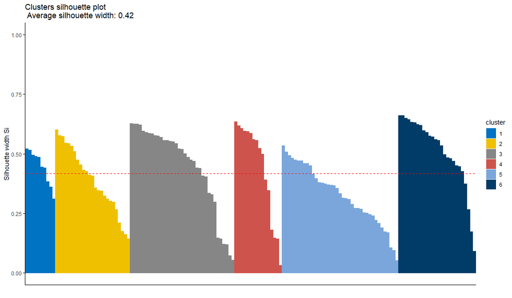

### Coeficientes de silhueta para cada indívíduo y<sub>i</sub>

```
##    cluster neighbor sil_width
## 6        1        2 0.5209484
## 4        1        2 0.5155121
## 7        1        2 0.4949843
## 5        1        2 0.4906690
## 3        1        4 0.4861582
## 8        1        2 0.4450594
## 2        1        2 0.4415461
## 1        1        4 0.3840257
## 10       1        2 0.3605553
## 12       1        2 0.3104518
```

### Indivíduos com Si negativo

Não se observa estabelecimentos com S_i negativos.

```
## [1] cluster   neighbor  sil_width
## <0 linhas> (ou row.names de comprimento 0)
```

Isso significa que todos os indivíduos estão alocados corretamente nos *cluster* gerados.

### Índice de Dun

O índice de Dunn identifica *clusters* densos e bem separados. É definida como a razão entre as distâncias mínimas entre os clusters e a distância máxima entre os clusters.

```
## [1] 0.005515741
```

O índice de Dunn tem um valor entre zero e infinito e deve ser maximizado. As pontuações de Dunn com alto valor são mais desejáveis. Nesta análise o valor é muito baixo, sugerindo que não é um bom agrupamento.

## Avaliação simultânea de algoritmos de agrupamento

O pacote `R clValid` (BROCK *et al.*, 2008) compara simultaneamente vários algoritmos de agrupamento em uma única chamada de função para identificar a melhor abordagem de agrupamento e o número ideal de agrupamentos (KASSAMBARA, 2017).

```
##
## Clustering Methods:
##  hierarchical kmeans pam
##
## Cluster sizes:
##  2 3 4 5 6
##
## Validation Measures:
##                                  2       3       4       5       6
##
## hierarchical Connectivity   3.6250  7.2829 17.1468 20.0587 22.0587
##              Dunn           0.2086  0.2086  0.0752  0.0942  0.0942
##              Silhouette     0.5830  0.5187  0.3761  0.4242  0.4177
## kmeans       Connectivity  22.5302 20.6480 35.3583 47.7175 49.7175
##              Dunn           0.0224  0.0235  0.0339  0.0323  0.0323
##              Silhouette     0.5195  0.3834  0.3999  0.4029  0.3946
## pam          Connectivity  19.7647 25.6599 29.1262 32.7095 34.3560
##              Dunn           0.0183  0.0280  0.0391  0.0235  0.0276
##              Silhouette     0.4005  0.3539  0.3771  0.4426  0.4113
##
## Optimal Scores:
##
##              Score  Method       Clusters
## Connectivity 3.6250 hierarchical 2
## Dunn         0.2086 hierarchical 2
## Silhouette   0.5830 hierarchical 2
```

Considerando três métodos de agrupamentos (hierárquico, kmeans e pam), os scores de validação interna (conectivdade, índice de Dunn e o coeficiente de silhueta) sugerem o método hierárquico e a formação de dois *clusters* para esse conjunto de dados.

## Medidas de estabilidade

As medidas de estabilidade avaliam a consistência de um resultado de agrupamento comparando-o com os agrupamentos obtidos após a remoção de cada coluna, um de cada vez (KASSAMBARA, 2017).

As medidas de estabilidade de *cluster* incluem:

- A proporção média de não sobreposição (APN);
- A distância média (AD);
- A distância média entre as médias (amc):
- A figura de mérito (FOM).

O APN, AD e amc são todos baseados no cruzamento tabela de classificação do agrupamento original nos dados completos com o agrupamento baseado na remoção de uma coluna (KASSAMBARA, 2017).

O APN mede a proporção média de indivíduos não colocadas no mesmo *cluster* agrupando com base nos dados completos e agrupando com base nos dados com uma única coluna removida (KASSAMBARA, 2017).

O AD mede a distância média entre os indivíduos colocados no mesmo *cluster* em ambos os casos (conjunto de dados completo e remoção de uma coluna) (KASSAMBARA, 2017).

O amc mede a distância média entre os centros dos *clusters* para indivíduos colocadas no mesmo *cluster* em ambos os casos (KASSAMBARA, 2017).

O FOM mede a variação intracluster média da coluna excluída, em que o agrupamento é baseado nas colunas restantes (não excluídas) (KASSAMBARA, 2017).

Os valores de APN, amc e FOM variam de 0 a 1, com valor menor correspondendo a resultados de agrupamento altamente consistentes. AD tem um valor entre 0 e infinito, e valores menores também são preferidos (KASSAMBARA, 2017).

```
##     Score       Method Clusters
## APN  0.02 hierarchical        2
## AD   1.05          pam        6
## ADM  0.26          pam        6
## FOM  0.52       kmeans        6
```

Observa-se que três medidas de estabilidade sugerem um número de 6 *clusters* para esse conjunto de dados. A medida FOM sugere o método kmeans para aplicar no algoritmo de agrupamento.

## Validação externa do agrupamento

Este processo consiste em comparar os resultados de uma análise de *cluster* com um resultado conhecido externamente, como rótulos de classe fornecidos externamente (KASSAMBARA, 2017).

Ele mede até que ponto os rótulos de **cluster** correspondem aos rótulos de classe fornecidos externamente. Usa-se essa abordagem para selecionar o melhor algoritmo de **cluster** para um conjunto de dados específico (KASSAMBARA, 2017).

O índice de Rand (HUBERT; ARABIE, 1985; RAND, 1971) fornece um valor entre 0 e 1, onde 1 significa que os dois resultados de agrupamento correspondem de forma idêntica.

O índice de Rand corrigido fornece uma medida para avaliar a similaridade entre duas partições, ajustadas ao acaso. Seu intervalo é de -1 (sem concordância) a 1 (concordância perfeita) (KASSAMBARA, 2017).

```
## [1] 1
```

```
## [1] 0
```

# Interpretação e validação dos *clusters*

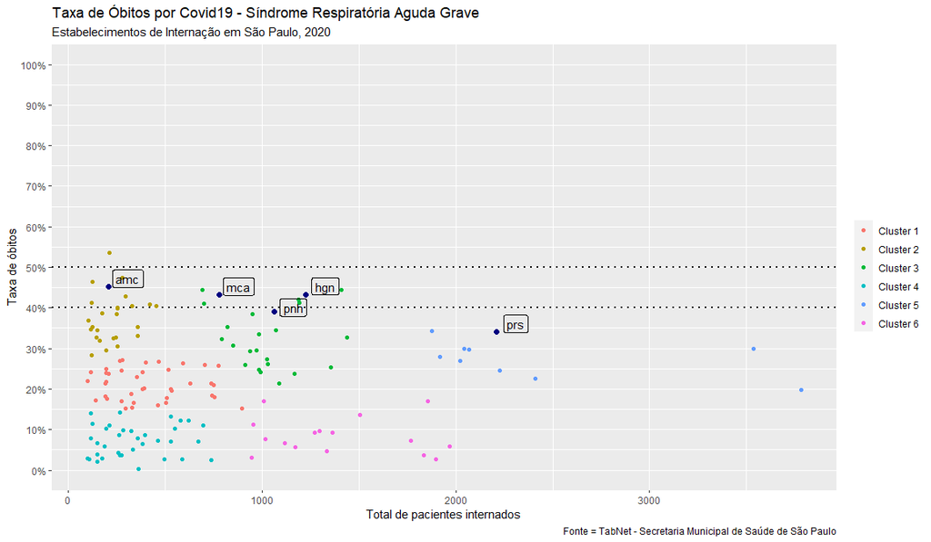

As linhas horizontais pontilhadas em cor preta representam os valores descritos na literatura para a mortalidade geral por SRAG, entre 40 e 50%, para SRAG moderada a grave (VILLAR; BLANCO; KACMAREK, 2016; VILLAR; SULEMANJI; KACMAREK, 2014).

# Base de dados de 2021

A base de dados para esta análise está disponível no aplicativo [TABNET](https://www.prefeitura.sp.gov.br/cidade/secretarias/saude/tabnet/index.php?p=296871) desenvolvido pelo DATASUS.

A Secretaria Municipal de Sáude de São Paulo disponibiliza o [TABNET](https://www.prefeitura.sp.gov.br/cidade/secretarias/saude/tabnet/index.php?p=296871) para o acesso às bases de dados de população e dos sistemas de informações do SUS.

## Carregando a base de dados

Esta análise traz o número de casos (**contéudo**) por estabelecimento de internação (**linha**) e por evolução (**coluna**) da página [COVID 19 Síndrome Respiratória Aguda Grave (SGAG)](http://tabnet.saude.prefeitura.sp.gov.br/cgi/tabcgi.exe?secretarias/saude/TABNET/RSRAG/sragh.def).

## Visão geral dos dados

Foram selecionados todos os estabelecimentos de internação y<sub>i</sub> que registraram um total de pelo menos 100 casos de SRAG , em 2021, em suas dependências.

```
## Rows: 137
## Columns: 8
## $ estab_inter  <chr> "2077531 A C CAMARGO CANCER CENTER", "6430120 BP MIRANTE"…
## $ cura         <int> 139, 111, 250, 670, 1114, 113, 1367, 379, 382, 1617, 445,…
## $ obito        <int> 35, 20, 60, 86, 270, 18, 576, 60, 43, 130, 39, 120, 30, 5…
## $ obito_outros <dbl> 1, 0, 0, 5, 2, 0, 28, 4, 6, 3, 5, 1, 3, 53, 49, 0, 1, 0, …
## $ ignorado     <dbl> 0, 4, 1, 29, 3, 0, 11, 2, 0, 0, 5, 0, 1, 10, 4, 3, 0, 3, …
## $ sem_info     <dbl> 8, 20, 2, 1, 34, 75, 4, 120, 0, 0, 130, 2, 1, 1, 12, 6, 2…
## $ total        <int> 183, 155, 313, 791, 1423, 206, 1986, 565, 431, 1750, 624,…
## $ taxa_ob      <dbl> 0.19125683, 0.12903226, 0.19169329, 0.10872314, 0.1897399…
```

Em 2021, 137 estabelecimentos de internação registrados no TABNET internaram pelo menos 100 pacientes com SRAG em suas dependências.

## Entendimento da base de dados

```
##   rows columns discrete_columns continuous_columns all_missing_columns
## 1  137       8                1                  7                   0
##   total_missing_values complete_rows total_observations memory_usage
## 1                    0           137               1096        22936
```

Observa-se que:

- Todas as variáveis x<sub>ij</sub> são quantitativas (*int* e *dbl*);
- Há 137 estabelecimentos de internação selecionados (y<sub>i</sub>);
- Não há *missing values* nos dados selecionados.

## Tipos de valores e ocorrência de valores ausentes.

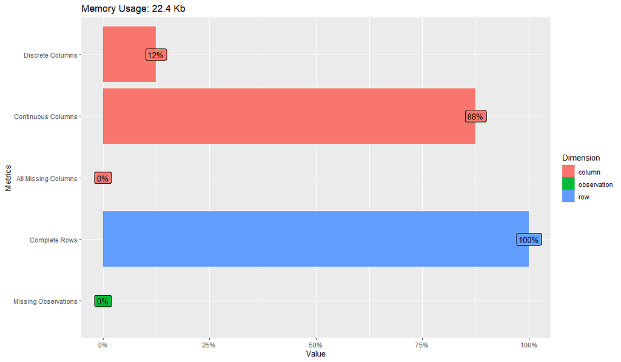

## Perfil dos valores ausentes

## Correlação entre as variáveis

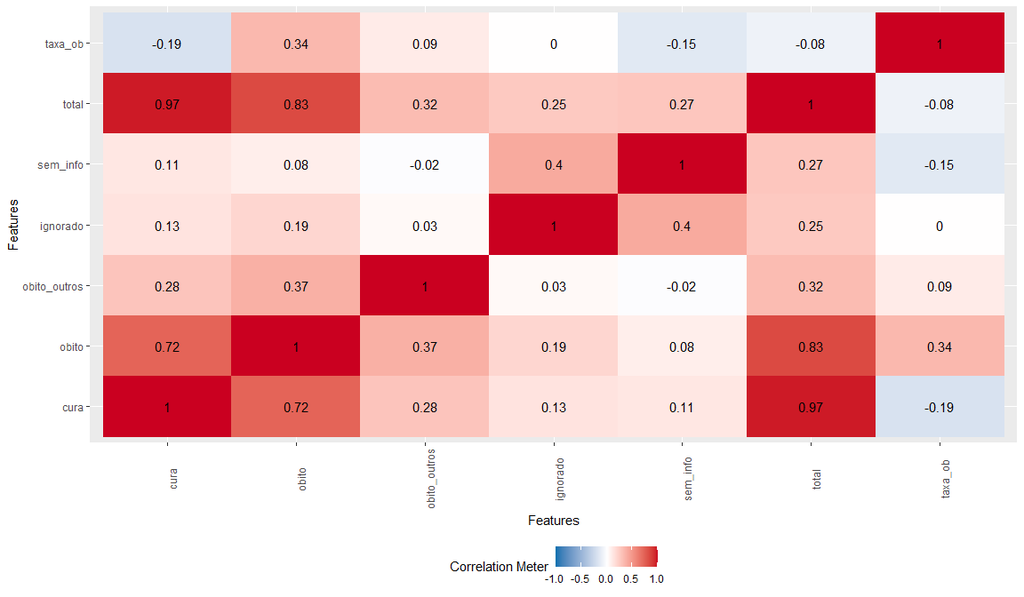

## Distribuição das variáveis quantitativas

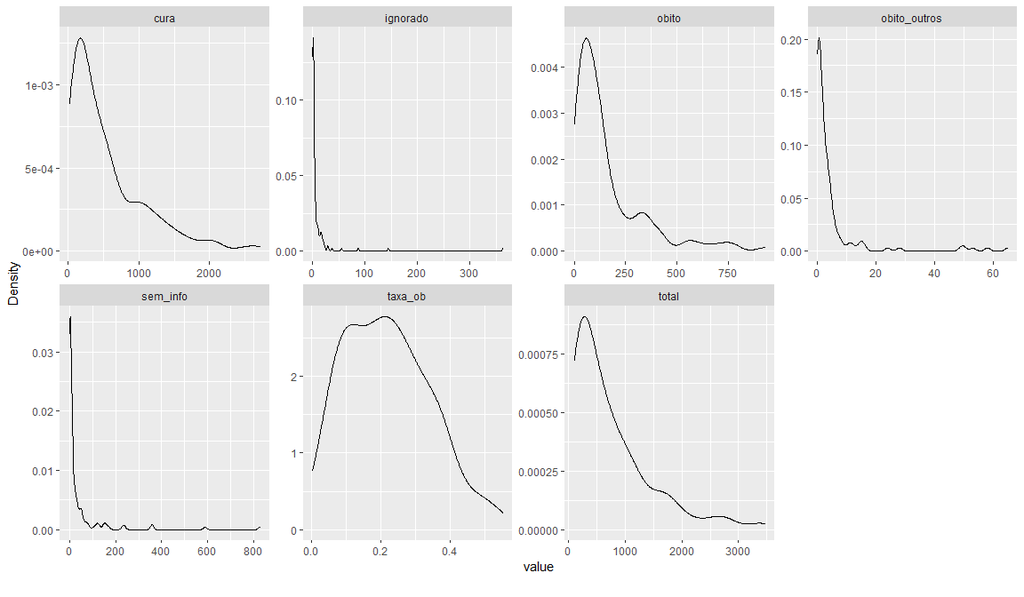

Observa-se forte assimetria positiva (à direita) para todas as variáveis.

# Preparação dos dados

Para fins desta análise foram considerados todos os estabelecimentos de internação com um número igual ou maior a 100 casos de internação/ano. Foram identificados 137 estabelecimentos de internação com esta característica.

No TABNET, no objeto evolução constam cinco variáveis x<sub>ij</sub> : cura, óbito, óbito por outras causas, ignorado e sem informação. As variáveis selecionadas para esta análise foram **cura**, **óbito** e **total de casos**. A variável **taxa de óbito** é a razão entre as variáveis **óbito** e **total de casos**.

As variáveis **óbito por outras causas**, **ignorado** e **sem informação** foram excluídas da análise por serem pouco discriminativas, mas foram absorvidas na variável total de internações.

```
##   cura obito total    taxa_ob
## 1  139    35   183 0.19125683
## 2  111    20   155 0.12903226
## 3  250    60   313 0.19169329
## 4  670    86   791 0.10872314
## 5 1114   270  1423 0.18973999
## 6  113    18   206 0.08737864
```

## Resumo sumário das variáveis

A próxima saída trás os valores de seis medidas (em ordem crescente):

- **Menor valor** (*Min*): o menor valor da variável registrada em algum estabelecimento de internação.
- **Primeiro quartil Q<sub>1</sub>** (*1st Qu*): 25% dos estabelecimentos de internação registraram uma medida da variável abaixo desse valor.
- **Mediana Q<sub>2</sub>** (*median*): 50% dos estabelecimentos de internação registraram uma medida da variável abaixo desse valor.
- **Média** (*mean*): média aritmética dos valores da variável registrada pelos estabelecimentos de internação.
- **Terceiro quartil Q<sub>3</sub>** (*3rd Qu*): 75% dos estabelecimentos de internação registraram uma medida da variável abaixo desse valor.
- **Maior valor** (*Max*): o maior valor da variável registrada em algum estabelecimento de internação.

```
##       cura            obito           total           taxa_ob
##  Min.   :  25.0   Min.   :  1.0   Min.   : 102.0   Min.   :0.002358
##  1st Qu.: 145.0   1st Qu.: 44.0   1st Qu.: 218.0   1st Qu.:0.117155
##  Median : 369.0   Median : 98.0   Median : 543.0   Median :0.207337
##  Mean   : 543.5   Mean   :158.1   Mean   : 753.7   Mean   :0.219386
##  3rd Qu.: 715.0   3rd Qu.:198.0   3rd Qu.:1035.0   3rd Qu.:0.300613
##  Max.   :2708.0   Max.   :927.0   Max.   :3465.0   Max.   :0.552845
```

À guisa de exemplo, considere a variável **taxa de óbito**:

Nos estabelecimentos de internação selecionados, se verifica que a média da taxa de óbitos por SRAG foi de 21.94% (12.38%).

A linha central marca a mediana do banco de dados. O valor da da mediana foi de 20.73%. Dito de outra maneira, em 2021, 50% dos estabelecimentos de internação da região metropolitana de São Paulo registraram uma taxa de óbito por SRAG inferior a 20.73%.

Em 2021, foram registradas 108.046 casos de COVID 19 SRAG no [TABNET](http://tabnet.saude.prefeitura.sp.gov.br/cgi/tabcgi.exe?secretarias/saude/TABNET/RSRAG/sragh.def), dos quais, 23.106 casos evoluíram para óbito (taxa de óbito = 21.38%)

Observe que 25% dos estabelecimentos de internação registraram uma taxa de óbitos por SRAG igual ou maior a 30.06%.

A taxa máxima de óbito registrada em 2021 foi de 55.28% e não se configura como *outiler*.

Estas informações podem ser visualizadas no seguinte *boxplot*.

### *Boxplot* da taxa de óbitos

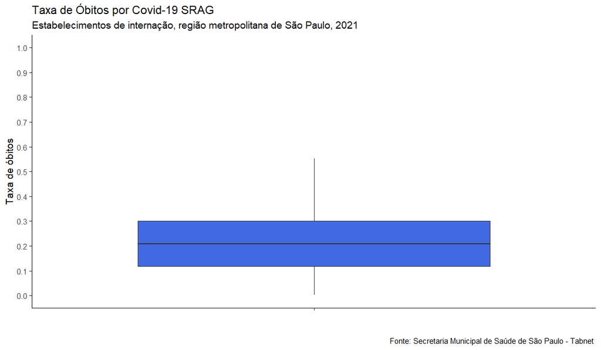

#### Pesquisa de *outliers*

Não se verifica *outliers* na taxa de óbito em 2021.

```
## numeric(0)
```

| estab_inter | total | taxa_ob |
| --- | --- | --- |
| 2077450 HOSP MUN DR JOSE SOARES HUNGRIA | 673 | 0.5289747 |
| 9255826 HOSPITAL E MATERNIDADE GUARULHOS | 117 | 0.4017094 |
| 2078082 HOSPITAL E MATERNIDADE METROPOLITANO | 205 | 0.4780488 |
| 2823209 HOSPITAL E PRONTO SOCORRO PORTINARI | 279 | 0.4695341 |
| 2091585 HOSPITAL ESTADUAL DE SAPOPEMBA SAO PAULO | 387 | 0.4134367 |
| 2084333 HOSPITAL IGESP | 238 | 0.4831933 |
| 5935857 HOSPITAL MUNICIPAL DE EMERGENCIAS ALBERT SABIN | 102 | 0.4607843 |
| 9131434 HOSPITAL SANCTA MAGGIORE HIGIENOPOLIS | 820 | 0.4048780 |
| 9620494 HOSPITAL SANTA ANA | 135 | 0.5111111 |
| 2088495 INSTITUTO DANTE PAZZANESE DE CARDIOLOGIA IDPC SAO PAULO | 123 | 0.5528455 |
| 2069032 UPA JULIO TUPY | 296 | 0.4121622 |

Observa-se que 11 estabelecimentos (8.03%) registraram uma taxa de óbito acima de 40% em 2021.

| estab_inter | total | taxa_ob |
| --- | --- | --- |
| 2078627 DAY HOSPITAL DE ERMELINO MATARAZZO | 206 | 0.0873786 |
| 2082314 HOSP ALBERT SABIN | 431 | 0.0997680 |
| 2089238 HOSP ALVORADA | 1750 | 0.0742857 |
| 2078481 HOSP AVICCENA | 624 | 0.0625000 |
| 2078406 HOSP INDEPENDENCIA | 146 | 0.0410959 |
| 2079186 HOSP MUN MAT ESC DR MARIO DE MORAES A SILVA | 192 | 0.0156250 |
| 2089599 HOSP NSRA DE LOURDES | 799 | 0.0638298 |
| 2080818 HOSP SAMARITANO | 1013 | 0.0868707 |
| 2688611 HOSP SAO LUIZUNIDADE I | 844 | 0.0687204 |
| 2079127 HOSP SIRIO LIBANES | 1484 | 0.0768194 |
| 2688603 HOSP STA CATARINA | 2063 | 0.0542899 |
| 2078597 HOSP STA HELENA | 257 | 0.0856031 |
| 2081628 HOSPITAL CARLOS CHAGAS | 189 | 0.0846561 |
| 2091801 HOSPITAL CENTRAL DE GUAIANASES | 213 | 0.0375587 |
| 2080168 HOSPITAL DA CRIANCA | 424 | 0.0023585 |
| 2789590 HOSPITAL E MATERNIDADE BRASIL | 170 | 0.0823529 |
| 2088517 HOSPITAL INFANTIL CANDIDO FONTOURA SAO PAULO | 930 | 0.0193548 |
| 6614426 HOSPITAL INFANTIL SABARA | 133 | 0.0075188 |
| 2058391 HOSPITAL ISRAELITA ALBERT EINSTEIN | 1640 | 0.0792683 |
| 6283993 HOSPITAL LEFORTE | 531 | 0.0546139 |
| 2089777 HOSPITAL NIPO BRASILEIRO | 1151 | 0.0564726 |
| 2076950 HOSPITAL OSWALDO CRUZ | 1090 | 0.0834862 |
| 2688565 HOSPITAL SAO CAMILO POMPEIA | 1855 | 0.0657682 |
| 9194258 HOSPITAL SAO LUIZ SAO CAETANO | 387 | 0.0671835 |
| 9735372 HOSPITAL VILA NOVA STAR | 140 | 0.0785714 |
| 2075407 PS MUN V MARIA BAIXA | 195 | 0.0871795 |
| 3824802 SAO LUIZ UNIDADE MORUMBI | 1333 | 0.0480120 |
| 7638698 UPA VILA SANTA CATARINA | 116 | 0.0775862 |

Observa-se que 28 estabelecimentos (20.44%) registraram uma taxa de óbito abaixo de 10% em 2021.

### *Boxplot* do número absoluto de pacientes curados

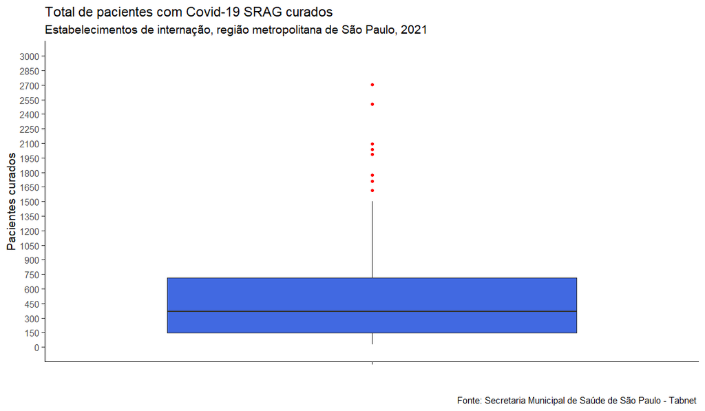

#### Pesquisa de *outliers*

```
## [1] 1617 2091 2036 2506 2708 1985 1774 1712
```

| estab_inter | cura | taxa_ob |
| --- | --- | --- |
| 2089238 HOSP ALVORADA | 1617 | 0.0742857 |
| 5718368 HOSP MUN M BOI MIRIM | 2091 | 0.1703932 |
| 2080583 HOSP MUN TIDE SETUBAL | 2036 | 0.2621866 |
| 2077477 HOSP STA MARCELINA SAO PAULO | 2506 | 0.2253968 |
| 0161438 HOSPITAL MUNICIPAL GUARAPIRANGA | 2708 | 0.1671696 |
| 9554157 HOSPITAL SALVALUS | 1985 | 0.2517850 |
| 7174721 HOSPITAL SANCTA MAGGIORE PARAISO | 1774 | 0.3353835 |
| 2688565 HOSPITAL SAO CAMILO POMPEIA | 1712 | 0.0657682 |

Observa-se a presença de 8 estabelecimentos (5.84%) que registraram um número absoluto de pacientes curados acima do padrão geral (*outliers*) em 2021.

### *Boxplot* do número absoluto de óbitos

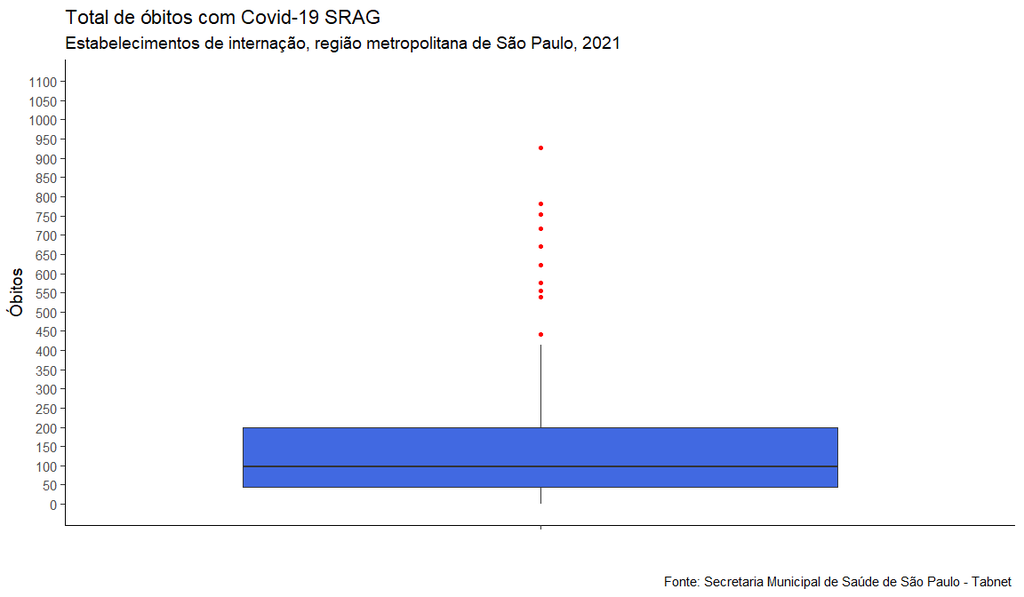

#### Presença de *outliers*

```
##  [1] 576 539 717 442 753 781 621 554 670 927
```

| estab_inter | obito | taxa_ob |
| --- | --- | --- |
| 2078015 HC DA FMUSP HOSPITAL DAS CLINICAS SAO PAULO | 576 | 0.2900302 |
| 2058502 HOSP DO SERV PUB EST FCO MORATO DE OLIVEIRA SAO PAULO | 539 | 0.2922993 |
| 9465464 HOSP MUN JOSANIAS CASTANHA BRAGA | 717 | 0.3247283 |
| 5718368 HOSP MUN M BOI MIRIM | 442 | 0.1703932 |
| 2080583 HOSP MUN TIDE SETUBAL | 753 | 0.2621866 |
| 2077477 HOSP STA MARCELINA SAO PAULO | 781 | 0.2253968 |
| 2077426 HOSPITAL ESTADUAL DE VILA ALPINA ORG SOCIAL SECONCI SAO PAUL | 621 | 0.3802817 |
| 0161438 HOSPITAL MUNICIPAL GUARAPIRANGA | 554 | 0.1671696 |
| 9554157 HOSPITAL SALVALUS | 670 | 0.2517850 |
| 7174721 HOSPITAL SANCTA MAGGIORE PARAISO | 927 | 0.3353835 |

Observa-se a presença de 10 estabelecimentos (7.3%) que registraram um número absoluto de óbitos acima do padrão geral (*outliers*)em 2021.

### *Boxplot* do total de internações

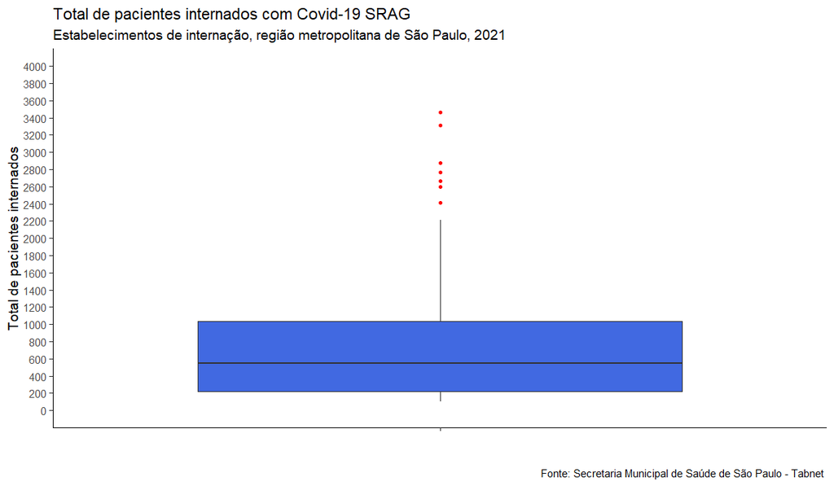

#### Presença de *outliers*

```
## [1] 2594 2872 3465 3314 2661 2764 2414
```

| estab_inter | total | taxa_ob |
| --- | --- | --- |
| 5718368 HOSP MUN M BOI MIRIM | 2594 | 0.1703932 |
| 2080583 HOSP MUN TIDE SETUBAL | 2872 | 0.2621866 |
| 2077477 HOSP STA MARCELINA SAO PAULO | 3465 | 0.2253968 |
| 0161438 HOSPITAL MUNICIPAL GUARAPIRANGA | 3314 | 0.1671696 |
| 9554157 HOSPITAL SALVALUS | 2661 | 0.2517850 |
| 7174721 HOSPITAL SANCTA MAGGIORE PARAISO | 2764 | 0.3353835 |
| 7479387 UPA III NOVA CAMPO LIMPO | 2414 | 0.1462303 |

Observa-se a presença de 7 estabelecimentos (5.11%) que registraram um número total de internações acima do padrão geral (*outliers*) em 2021.

## Padronização dos dados 2021

A utilização de variáveis com medidas e ou escalas diferentes podem distorcer a estrutura do *cluster*. Variáveis com maior dispersão têm maior peso para o cálculo das medidas de distância do que as demais.

A padronização dos dados faz com que seja atribuído o mesmo peso para cada variável. Neste estudo foi utilizada a transformação de cada variável em escore padrão (*Z score*). O método Z score padroniza cada variável de modo a apresentar uma média zero(0)e desvio padrão um (1):

$$Z = \frac{(x - média)}{desvio \ padrão}$$

```
##            cura      obito       total    taxa_ob
## [1,] -0.7487930 -0.6952474 -0.80452395 -0.2272037
## [2,] -0.8006287 -0.7799583 -0.84399489 -0.7298020
## [3,] -0.5433016 -0.5540626 -0.62126602 -0.2236783
## [4,]  0.2342334 -0.4072305  0.05255932 -0.8938422
## [5,]  1.0561991  0.6318895  0.94347483 -0.2394555
## [6,] -0.7969261 -0.7912531 -0.77210140 -1.0662453
```

# Modelagem estatística

> A partir do conceito filosófico de verissimilitude (MEEHL, apud (CHIN, 2010), os modelos perfeitos inexistem e variam no grau em que se assemelham à realidade que se propõem representar. Isto pode ser analisado sob duas perspectivas: a incompletude (*incompleteness*), que trata do quão bem as complexidades do mundo real são representadas pelo modelo, e a inexatidão (*falseness*), que explora como as contradições entre o modelo e o mundo real são adequadamente expressas (CHIN, 2010). Cabe, pois, ao pesquisador, segundo essa concepção, não questionar se o modelo é verídico, mas como ele é autêntico e em que extensão ele se aproxima da realidade (ROZEBOOM, 2005).

> Antonio Sergio da Silva (SILVA, 2014)

## Método *K-means*

O algoritmo *K-means* é o algoritmo de agrupamento particional mais utilizado baseado no critério da soma dos quadrados (KASSAMBARA, 2017; MACQUEEN, 1967). Trata-se de um algoritmo simples, fácil de implementação e implementado em quase todos os *softwares* de mineração de dados. Ademais, é muito versátil, considerando os aspectos inicialização, distância, função, critério de finalização.

À guisa de exemplo, considere uma classificação de imagens de animais. Uma questão importante poderia ser a imagem de um cão. Qualquer imagem que se pareça com um cão ou partes de um cão, será classificado neste *cluster*. Imagens de peixes e aves ficarão distantes desta classificação e aparecerão em outros *clusters*.

## Determinação do número de *clusters*

O método *k-means* é um procedimento não hierárquico para agrupar indivíduos, cujo número inicial de *clusters* é definido pelo pesquisador (FÁVERO; BELFIORE, 2017; KASSAMBARA, 2017).

A análise visual a partir de um gráfico de linhas de duas dimensões: os *K Clusters* (*Number of clusters k*) e a Soma dos Quadrados dos Erros de Predição (*Total Within Sum of Square - SSE*) sugere um número inicial de *clusters* para ser usado. O SSE resulta na variância e desvio padrão (inércia) dos dados da base utilizada. Desta forma pode-se visualizar o valor de quão próximo os dados estão uns dos outros. Quanto menor for o número de *clusters*, maior será o valor dessa inércia (KASSAMBARA, 2017).

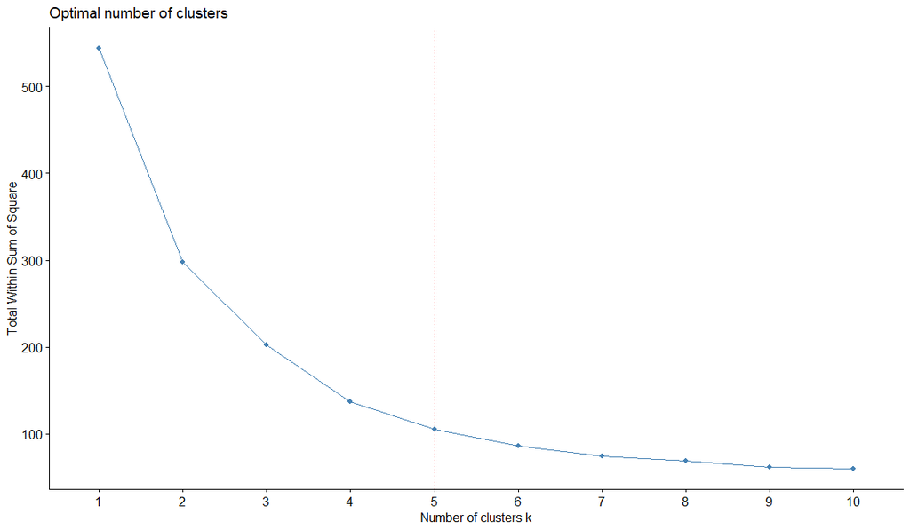

O gráfico acima representa a variação dentro dos *clusters*. Nota-se que a partir do quinto *cluster*, o valor do SSE não tem mais grandes variações. Aumentar o número de *clusters* indica que esta variação se tornaria cada vez menor.

Sendo assim, a quantidade de cinco ou seis *clusters* parece ser um número bem interessante para se aplicar nesse conjunto de dados.

## Visualização gráfica dos *clusters*

O algoritmo para determinar a alocação das observações em cada conglomerado é denominado *nearest centroid sorting*. O *K-means* usa a distância euclidiana como critério de distância para formar os grupos.

A função `fviz_cluster()` do pacote `fatoextra` pode ser usada para visualizar facilmente os *clusters k-means*. No gráfico resultante, as observações são representadas por pontos, usando análise de componentes principais (PCA) quando o número de variáveis x<sub>ij</sub>for maior do que 2 (KASSAMBARA, 2017).

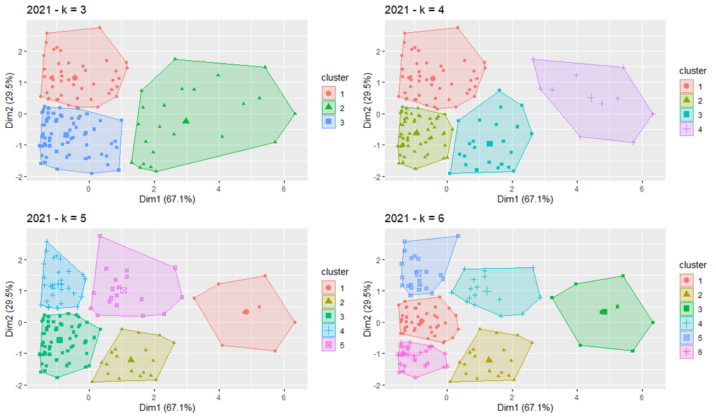

Considerando-se a formação com k = 5 grupos (*clusters*), pode-se perceber que os grupos formados apresentam homogeneidade interna (variabilidade dentro dos grupos), com cada estabelecimento de internação apresentando maior proximidade com outros estabelecimentos do mesmo grupo, do que com estabelecimentos de internação de outros grupos (variabilidade entre os grupos).

## Agrupar *cluster* e base

|  | estab_inter | cura | obito | obito_outros | ignorado | sem_info | total | taxa_ob | evolucao21.k5.cluster |
| --- | --- | --- | --- | --- | --- | --- | --- | --- | --- |
| 7 | 2078015 HC DA FMUSP HOSPITAL DAS CLINICAS SAO PAULO | 1367 | 576 | 28 | 11 | 4 | 1986 | 0.2900302 | 1 |
| 30 | 9465464 HOSP MUN JOSANIAS CASTANHA BRAGA | 1472 | 717 | 0 | 7 | 12 | 2208 | 0.3247283 | 1 |
| 31 | 5718368 HOSP MUN M BOI MIRIM | 2091 | 442 | 0 | 10 | 51 | 2594 | 0.1703932 | 1 |
| 35 | 2080583 HOSP MUN TIDE SETUBAL | 2036 | 753 | 4 | 13 | 66 | 2872 | 0.2621866 | 1 |
| 49 | 2077477 HOSP STA MARCELINA SAO PAULO | 2506 | 781 | 65 | 7 | 106 | 3465 | 0.2253968 | 1 |
| 92 | 0161438 HOSPITAL MUNICIPAL GUARAPIRANGA | 2708 | 554 | 0 | 16 | 36 | 3314 | 0.1671696 | 1 |
| 99 | 9554157 HOSPITAL SALVALUS | 1985 | 670 | 1 | 2 | 3 | 2661 | 0.2517850 | 1 |
| 104 | 7174721 HOSPITAL SANCTA MAGGIORE PARAISO | 1774 | 927 | 8 | 2 | 53 | 2764 | 0.3353835 | 1 |
| 5 | 2077574 CONJUNTO HOSPITALAR DO MANDAQUI SAO PAULO | 1114 | 270 | 2 | 3 | 34 | 1423 | 0.1897400 | 2 |
| 10 | 2089238 HOSP ALVORADA | 1617 | 130 | 3 | 0 | 0 | 1750 | 0.0742857 | 2 |
| 20 | 2078589 HOSP MAT STA MARIA-CRUZ AZUL | 1248 | 230 | 12 | 1 | 169 | 1660 | 0.1385542 | 2 |
| 41 | 2080818 HOSP SAMARITANO | 913 | 88 | 2 | 1 | 9 | 1013 | 0.0868707 | 2 |
| 45 | 2079127 HOSP SIRIO LIBANES | 1319 | 114 | 1 | 1 | 49 | 1484 | 0.0768194 | 2 |
| 46 | 2688603 HOSP STA CATARINA | 1119 | 112 | 3 | 3 | 826 | 2063 | 0.0542899 | 2 |
| 55 | 2080575 HOSPITAL BP | 952 | 140 | 0 | 1 | 40 | 1133 | 0.1235658 | 2 |
| 62 | 7992890 HOSPITAL DIA REDE HORA CERTA DA CAPELA DO SOCORRO | 1502 | 198 | 0 | 20 | 11 | 1731 | 0.1143847 | 2 |
| 78 | 2077671 HOSPITAL GERAL DO GRAJAU PROF LIBER JOHN ALPHONSE DI DIO SP | 976 | 156 | 4 | 14 | 26 | 1176 | 0.1326531 | 2 |
| 83 | 2088517 HOSPITAL INFANTIL CANDIDO FONTOURA SAO PAULO | 907 | 18 | 0 | 1 | 4 | 930 | 0.0193548 | 2 |
| 85 | 2058391 HOSPITAL ISRAELITA ALBERT EINSTEIN | 1503 | 130 | 4 | 3 | 0 | 1640 | 0.0792683 | 2 |
| 89 | 0102075 HOSPITAL MUNICIPAL BELA VISTA | 1358 | 318 | 2 | 1 | 22 | 1701 | 0.1869489 | 2 |
| 94 | 2089777 HOSPITAL NIPO BRASILEIRO | 1053 | 65 | 11 | 16 | 6 | 1151 | 0.0564726 | 2 |
| 96 | 2076950 HOSPITAL OSWALDO CRUZ | 989 | 91 | 3 | 0 | 7 | 1090 | 0.0834862 | 2 |
| 98 | 2091313 HOSPITAL REGIONAL SUL SAO PAULO | 928 | 235 | 3 | 1 | 4 | 1171 | 0.2006832 | 2 |
| 113 | 2688565 HOSPITAL SAO CAMILO POMPEIA | 1712 | 122 | 4 | 10 | 7 | 1855 | 0.0657682 | 2 |
| 120 | 6668143 HOSPITAL VITORIA | 1054 | 137 | 0 | 3 | 6 | 1200 | 0.1141667 | 2 |
| 129 | 3824802 SAO LUIZ UNIDADE MORUMBI | 1228 | 64 | 15 | 0 | 26 | 1333 | 0.0480120 | 2 |
| 133 | 7479387 UPA III NOVA CAMPO LIMPO | 1107 | 353 | 3 | 363 | 588 | 2414 | 0.1462303 | 2 |
| 1 | 2077531 A C CAMARGO CANCER CENTER | 139 | 35 | 1 | 0 | 8 | 183 | 0.1912568 | 3 |
| 2 | 6430120 BP MIRANTE | 111 | 20 | 0 | 4 | 20 | 155 | 0.1290323 | 3 |
| 3 | 3464555 CENTRO MEDICO PMESP | 250 | 60 | 0 | 1 | 2 | 313 | 0.1916933 | 3 |

[output cut: 107 more lines]

## Resumo do modelo 2021

### Média aritmética

| evolucao21.k5$cluster | cura | obito | total | taxa_ob |
| --- | --- | --- | --- | --- |
| 1 | 1992.38 | 677.50 | 2733.00 | 0.25 |
| 2 | 1189.42 | 156.37 | 1469.37 | 0.10 |
| 3 | 294.15 | 57.34 | 389.07 | 0.14 |
| 4 | 163.93 | 103.63 | 290.80 | 0.37 |
| 5 | 687.21 | 350.68 | 1106.32 | 0.32 |

### Desvio padrão

| evolucao21.k5$cluster | cura | obito | total | taxa_ob |
| --- | --- | --- | --- | --- |
| 1 | 462.48 | 151.80 | 500.26 | 0.06 |
| 2 | 249.79 | 89.13 | 393.42 | 0.05 |
| 3 | 198.13 | 43.95 | 231.67 | 0.07 |
| 4 | 95.55 | 51.89 | 152.75 | 0.08 |
| 5 | 259.68 | 104.02 | 335.83 | 0.07 |

### Coeficiente de variação

| evolucao21.k5$cluster | cura | obito | total | taxa_ob |
| --- | --- | --- | --- | --- |
| 1 | 23.21 | 22.41 | 18.30 | 25.11 |
| 2 | 21.00 | 57.00 | 26.77 | 48.96 |
| 3 | 67.36 | 76.65 | 59.55 | 46.81 |
| 4 | 58.28 | 50.07 | 52.53 | 21.19 |
| 5 | 37.79 | 29.66 | 30.36 | 21.83 |

## Validação interna do agrupamento

A validação de agrupamento consiste em projetar o procedimento de avaliação da qualidade dos resultados do algoritmo de agrupamento.

Isso é importante para evitar encontrar padrões em dados aleatórios, bem como na situação em que se deseja a comparação entre dois algoritmos de agrupamento (KASSAMBARA, 2017).

O processo de validação interna usa as informações internas do processo do agrupamento para avaliar a qualidade de uma estrutura de agrupamento, aquém de informações externas. O processo é capaz de estimar o número de **clusters** e o algoritmo de agrupamento apropriado sem nenhum dado externo (KASSAMBARA, 2017).

Medidas internas usam informações intrínsecas nos dados para avaliar a qualidade do agrupamento (KASSAMBARA, 2017).

As medidas internas incluem a conectividade, o coeficiente de silhueta e o índice de Dunn.

### Conectividade

A conectividade corresponde à medida em que os itens são colocados no mesmo *cluster* que seus vizinhos mais próximos no espaço de dados. A conectividade tem um valor entre 0 e infinito e deve ser minimizada (KASSAMBARA, 2017).

### Coeficiente de silhueta

O coeficiente de silhueta (S_i) mede a semelhança de um indivíduo y<sub>i</sub> com os outros indivíduos em seu próprio *cluster* versus os do *cluster* vizinho (KASSAMBARA, 2017).

Os valores de S_i variam de -1 a +1:

- Um valor de S_i próximo a 1 indica que o indivíduo está bem agrupado. Isto é, o indivíduo y<sub>i</sub> é semelhante aos outros índivíduos em seu grupo (KASSAMBARA, 2017).
- Um valor de S_i próximo a -1 indica que o indivíduo está mal agrupado e que a atribuição a algum outro agrupamento provavelmente melhoraria os resultados gerais (KASSAMBARA, 2017).

```
##   cluster size ave.sil.width
## 1       1   61          0.43
## 2       2    8          0.44
## 3       3   19          0.31
## 4       4   30          0.47
## 5       5   19          0.42
```

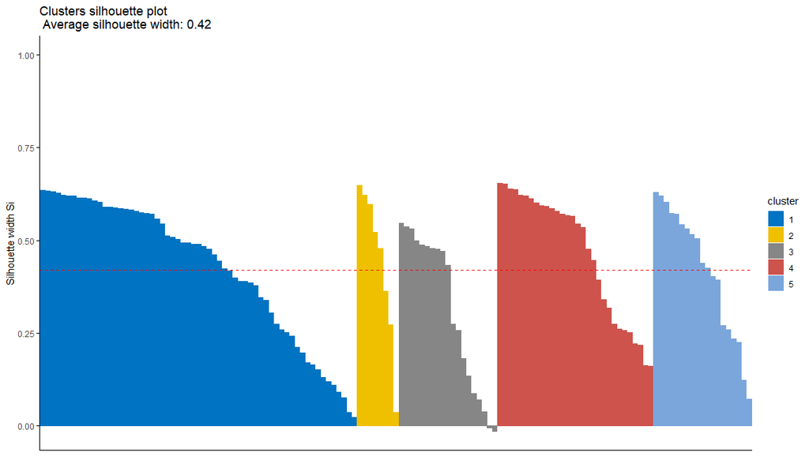

### Coeficientes de silhueta para cada indívíduo y<sub>i</sub>

Abaixo segue a relação dos 10 estabelecimentos (y<sub>i</sub>)com os maiores coeficientes S-i

```
##     cluster neighbor sil_width
## 9         1        4 0.6353334
## 48        1        4 0.6335838
## 95        1        4 0.6322701
## 63        1        4 0.6276324
## 56        1        4 0.6215085
## 126       1        4 0.6205555
## 115       1        5 0.6204042
## 64        1        4 0.6150153
## 50        1        4 0.6144370
## 6         1        4 0.6127469
```

### Indivíduos com Si negativo

Observa-se 2 estabelecimentos com S_i negativos.

```
##    cluster neighbor    sil_width
## 79       3        4 -0.004126102
## 26       3        4 -0.014490314
```

Isso significa que 2 indivíduos estão alocados incorretamente nos *cluster* gerados.

### Índice de Dun

O índice de Dunn identifica *clusters* densos e bem separados. É definida como a razão entre as distâncias mínimas entre os clusters e a distância máxima entre os clusters.

```
## [1] 0.01167727
```

O índice de Dunn tem um valor entre zero e infinito e deve ser maximizado. As pontuações de Dunn com alto valor são mais desejáveis. Nesta análise o valor é muito baixo, sugerindo que não é um bom agrupamento.

## Avaliação simultânea de algoritmos de agrupamento

O pacote `R clValid` (BROCK *et al.*, 2008) compara simultaneamente vários algoritmos de agrupamento em uma única chamada de função para identificar a melhor abordagem de agrupamento e o número ideal de agrupamentos (KASSAMBARA, 2017).

```
##
## Clustering Methods:
##  hierarchical kmeans pam
##
## Cluster sizes:
##  2 3 4 5
##
## Validation Measures:
##                                  2       3       4       5
##
## hierarchical Connectivity   6.1587 15.9460 20.7175 28.3929
##              Dunn           0.1491  0.0747  0.0747  0.0819
##              Silhouette     0.5885  0.4048  0.3859  0.3981
## kmeans       Connectivity  12.0500 23.2849 34.7758 40.9266
##              Dunn           0.0840  0.0597  0.0415  0.0866
##              Silhouette     0.5185  0.3903  0.4137  0.4192
## pam          Connectivity  16.4179 37.2738 53.8984 43.5905
##              Dunn           0.0542  0.0368  0.0153  0.0415
##              Silhouette     0.4396  0.3440  0.2615  0.3327
##
## Optimal Scores:
##
##              Score  Method       Clusters
## Connectivity 6.1587 hierarchical 2
## Dunn         0.1491 hierarchical 2
## Silhouette   0.5885 hierarchical 2
```

Considerando três métodos de agrupamentos (hierárquico, kmeans e pam), os scores de validação interna (conectivdade, índice de Dunn e o coeficiente de silhueta) sugerem o método hierárquico e a formação de dois *clusters* para esse conjunto de dados.

## Medidas de estabilidade

As medidas de estabilidade avaliam a consistência de um resultado de agrupamento comparando-o com os agrupamentos obtidos após a remoção de cada coluna, um de cada vez (KASSAMBARA, 2017).

As medidas de estabilidade de *cluster* incluem:

- A proporção média de não sobreposição (APN);
- A distância média (AD);
- A distância média entre as médias (amc):
- A figura de mérito (FOM).

O APN, AD e amc são todos baseados no cruzamento tabela de classificação do agrupamento original nos dados completos com o agrupamento baseado na remoção de uma coluna (KASSAMBARA, 2017).

O APN mede a proporção média de indivíduos não colocadas no mesmo *cluster* agrupando com base nos dados completos e agrupando com base nos dados com uma única coluna removida (KASSAMBARA, 2017).

O AD mede a distância média entre os indivíduos colocados no mesmo *cluster* em ambos os casos (conjunto de dados completo e remoção de uma coluna) (KASSAMBARA, 2017).

O amc mede a distância média entre os centros dos *clusters* para indivíduos colocadas no mesmo *cluster* em ambos os casos (KASSAMBARA, 2017).

O FOM mede a variação intracluster média da coluna excluída, em que o agrupamento é baseado nas colunas restantes (não excluídas) (KASSAMBARA, 2017).

Os valores de APN, amc e FOM variam de 0 a 1, com valor menor correspondendo a resultados de agrupamento altamente consistentes. AD tem um valor entre 0 e infinito, e valores menores também são preferidos (KASSAMBARA, 2017).

```
##     Score       Method Clusters
## APN  0.02 hierarchical        2
## AD   1.32       kmeans        5
## ADM  0.16 hierarchical        2
## FOM  0.61       kmeans        5
```

Observa-se que duas medidas de estabilidade sugerem um número de 5 *clusters* para esse conjunto de dados. A medida FOM sugere o método kmeans para aplicar no algoritmo de agrupamento.

## Validação externa do agrupamento

Este processo consiste em comparar os resultados de uma análise de *cluster* com um resultado conhecido externamente, como rótulos de classe fornecidos externamente (KASSAMBARA, 2017).

Ele mede até que ponto os rótulos de **cluster** correspondem aos rótulos de classe fornecidos externamente. Usa-se essa abordagem para selecionar o melhor algoritmo de **cluster** para um conjunto de dados específico (KASSAMBARA, 2017).

O índice de Rand (HUBERT; ARABIE, 1985; RAND, 1971) fornece um valor entre 0 e 1, onde 1 significa que os dois resultados de agrupamento correspondem de forma idêntica.

O índice de Rand corrigido fornece uma medida para avaliar a similaridade entre duas partições, ajustadas ao acaso. Seu intervalo é de -1 (sem concordância) a 1 (concordância perfeita) (KASSAMBARA, 2017).

```
## [1] 1
```

```
## [1] -4.440892e-16
```

# Interpretação e validação dos *clusters*

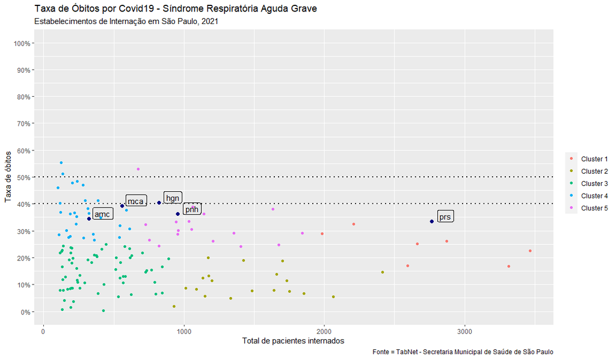

As linhas horizontais pontilhadas em cor preta representam os valores descritos na literatura para a mortalidade geral por SRAG, entre 40 e 50%, para SRAG moderada a grave (VILLAR; BLANCO; KACMAREK, 2016; VILLAR; SULEMANJI; KACMAREK, 2014).

# Base de dados de 2022

A base de dados para esta análise está disponível no aplicativo [TABNET](https://www.prefeitura.sp.gov.br/cidade/secretarias/saude/tabnet/index.php?p=296871) desenvolvido pelo DATASUS.

A Secretaria Municipal de Sáude de São Paulo disponibiliza o [TABNET](https://www.prefeitura.sp.gov.br/cidade/secretarias/saude/tabnet/index.php?p=296871) para o acesso às bases de dados de população e dos sistemas de informações do SUS.

## Carregando a base de dados

Esta análise traz o número de casos (**contéudo**) por estabelecimento de internação (**linha**) e por evolução (**coluna**) da página [COVID 19 Síndrome Respiratória Aguda Grave (SGAG)](http://tabnet.saude.prefeitura.sp.gov.br/cgi/tabcgi.exe?secretarias/saude/TABNET/RSRAG/sragh.def).

## Visão geral dos dados

Foram selecionados todos os estabelecimentos de internação y<sub>i</sub> que registraram um total de pelo menos 100 casos de SRAG , em 2022, em suas dependências.

```
## Rows: 69
## Columns: 8
## $ estab_inter  <chr> "2077531 A C CAMARGO CANCER CENTER", "2077574 CONJUNTO HO…
## $ cura         <int> 109, 701, 334, 143, 222, 502, 108, 179, 38, 107, 50, 169,…
## $ obito        <dbl> 17, 64, 101, 27, 12, 23, 2, 58, 37, 17, 19, 29, 6, 61, 28…
## $ obito_outros <dbl> 9, 0, 14, 0, 1, 2, 5, 7, 1, 0, 0, 0, 0, 0, 3, 1, 0, 0, 0,…
## $ ignorado     <dbl> 0, 103, 5, 0, 0, 0, 2, 6, 0, 0, 0, 1, 2, 1, 14, 10, 9, 39…
## $ sem_info     <dbl> 2, 83, 17, 64, 11, 9, 49, 6, 695, 3, 56, 13, 96, 17, 30, …
## $ total        <int> 137, 951, 471, 234, 246, 536, 166, 256, 771, 127, 125, 21…
## $ taxa_ob      <dbl> 0.124087591, 0.067297581, 0.214437367, 0.115384615, 0.048…
```

Em 2022, 69 estabelecimentos de internação registrados no TABNET internaram pelo menos 100 pacientes com SRAG em suas dependências.

## Entendimento da base de dados

```
##   rows columns discrete_columns continuous_columns all_missing_columns
## 1   69       8                1                  7                   0
##   total_missing_values complete_rows total_observations memory_usage
## 1                    0            69                552        13032
```

Observa-se que:

- Todas as variáveis x<sub>ij</sub> são quantitativas (*int* e *dbl*);
- Há 69 estabelecimentos de internação selecionados (y<sub>i</sub>);
- Não há *missing values* nos dados selecionados.

## Tipos de valores e ocorrência de valores ausentes.

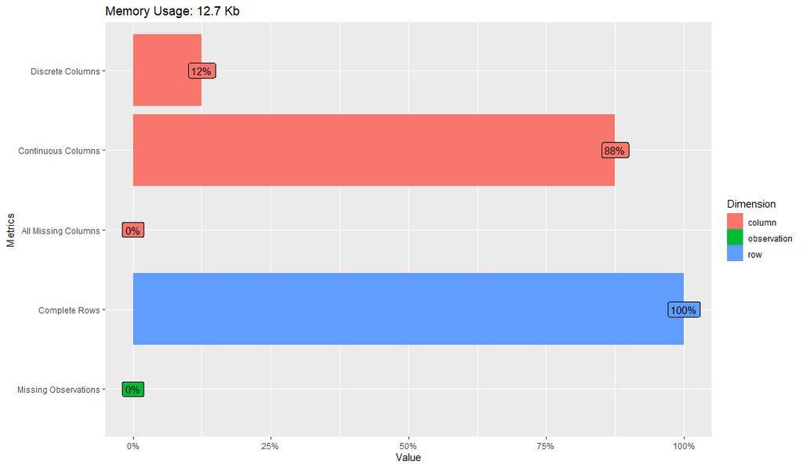

## Correlação entre as variáveis

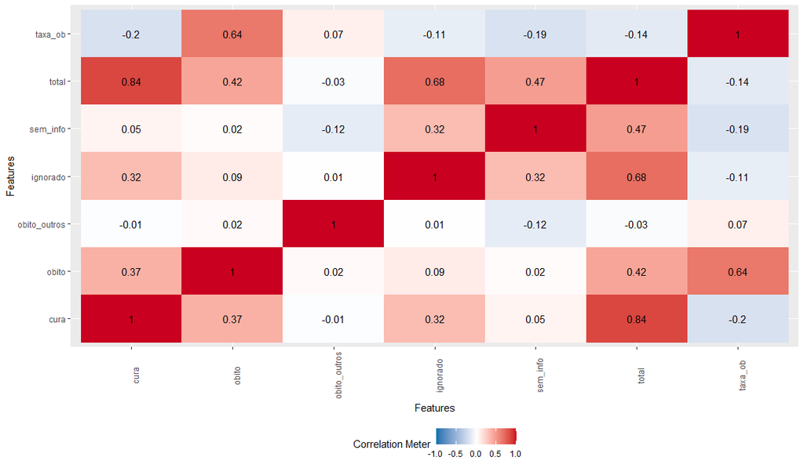

## Distribuição das variáveis quantitativas

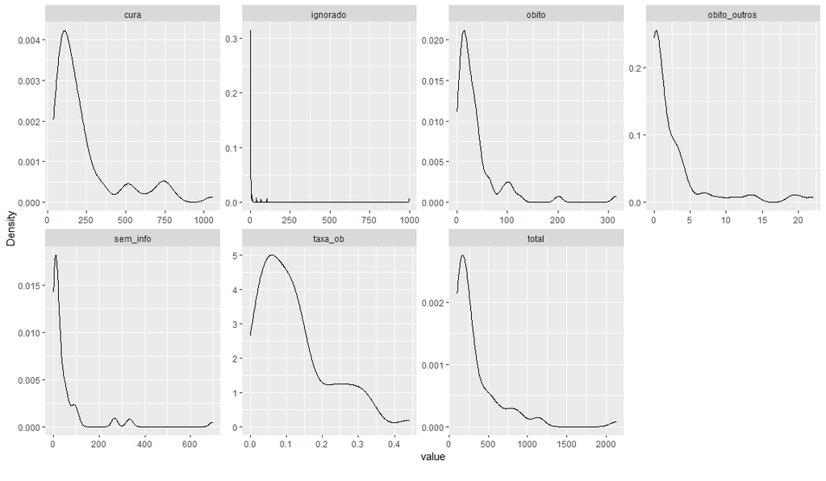

Observa-se forte assimetria positiva (à direita) para todas as variáveis, exceto para a variável taxa de óbito, cujo padrão é bimodal.

# Preparação dos dados

Para fins desta análise foram considerados todos os estabelecimentos de internação com um número igual ou maior a 100 casos de internação/ano. Foram identificados 69 estabelecimentos de internação com esta característica.

No TABNET, no objeto evolução constam cinco variáveis x<sub>ij</sub> : cura, óbito, óbito por outras causas, ignorado e sem informação. As variáveis selecionadas para esta análise foram **cura**, **óbito** e **total de casos**. A variável **taxa de óbito** é a razão entre as variáveis **óbito** e **total de casos**.

As variáveis **óbito por outras causas**, **ignorado** e **sem informação** foram excluídas da análise por serem pouco discriminativas, mas foram absorvidas na variável total de internações.

```
##   cura obito total    taxa_ob
## 1  109    17   137 0.12408759
## 2  701    64   951 0.06729758
## 3  334   101   471 0.21443737
## 4  143    27   234 0.11538462
## 5  222    12   246 0.04878049
## 6  502    23   536 0.04291045
```

## Resumo sumário das variáveis

A próxima saída trás os valores de seis medidas (em ordem crescente):

- **Menor valor** (*Min*): o menor valor da variável registrada em algum estabelecimento de internação.
- **Primeiro quartil Q<sub>1</sub>** (*1st Qu*): 25% dos estabelecimentos de internação registraram uma medida da variável abaixo desse valor.
- **Mediana Q<sub>2</sub>** (*median*): 50% dos estabelecimentos de internação registraram uma medida da variável abaixo desse valor.
- **Média** (*mean*): média aritmética dos valores da variável registrada pelos estabelecimentos de internação.
- **Terceiro quartil Q<sub>3</sub>** (*3rd Qu*): 75% dos estabelecimentos de internação registraram uma medida da variável abaixo desse valor.
- **Maior valor** (*Max*): o maior valor da variável registrada em algum estabelecimento de internação.

```
##       cura            obito            total           taxa_ob
##  Min.   :  38.0   Min.   :  0.00   Min.   : 100.0   Min.   :0.00000
##  1st Qu.:  98.0   1st Qu.: 12.00   1st Qu.: 137.0   1st Qu.:0.04577
##  Median : 157.0   Median : 22.00   Median : 227.0   Median :0.09852
##  Mean   : 233.8   Mean   : 36.55   Mean   : 343.2   Mean   :0.11914
##  3rd Qu.: 248.0   3rd Qu.: 39.00   3rd Qu.: 409.0   3rd Qu.:0.15418
##  Max.   :1052.0   Max.   :315.00   Max.   :2128.0   Max.   :0.44082
```

À guisa de exemplo, considere a variável **taxa de óbito**:

Nos estabelecimentos de internação selecionados, se verifica que a média da taxa de óbitos por SRAG foi de 11.91% (9.72%).

A linha central marca a mediana do banco de dados. O valor da da mediana foi de 9.85%. Dito de outra maneira, em 2022, 50% dos estabelecimentos de internação da região metropolitana de São Paulo registraram uma taxa de óbito por SRAG inferior a 9.85%.

Em 2022, foram registradas 28.232 casos de COVID 19 SRAG no [TABNET](http://tabnet.saude.prefeitura.sp.gov.br/cgi/tabcgi.exe?secretarias/saude/TABNET/RSRAG/sragh.def), dos quais, 3.502 casos evoluíram para óbito (taxa de óbito = 12.40%)

Observe que 25% dos estabelecimentos de internação registraram uma taxa de óbitos por SRAG igual ou maior a 15.42%.

A taxa máxima de óbito registrada em 2022 foi de 44.08% e se configura como *outiler*.

Estas informações podem ser visualizadas no seguinte *boxplot*.

### *Boxplot* da taxa de óbitos

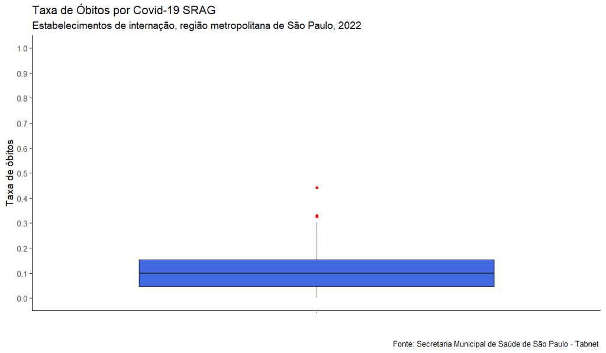

#### Pesquisa de *outliers*

Se verifica a presença de *outliers* na taxa de óbito em 2022.

```
## [1] 0.3270677 0.4408163 0.3263158 0.3291139
```

| estab_inter | total | taxa_ob |
| --- | --- | --- |
| 0102105 HOSPITAL MUNICIPAL BRASILANDIA | 245 | 0.4408163 |

Observa-se que 1 estabelecimentos (1.45%) registraram uma taxa de óbito acima de 40% em 2022.

| estab_inter | total | taxa_ob |
| --- | --- | --- |
| 2077574 CONJUNTO HOSPITALAR DO MANDAQUI SAO PAULO | 951 | 0.0672976 |
| 2082314 HOSP ALBERT SABIN | 246 | 0.0487805 |
| 2089238 HOSP ALVORADA | 536 | 0.0429104 |
| 2078481 HOSP AVICCENA | 166 | 0.0120482 |
| 2078589 HOSP MAT STA MARIA-CRUZ AZUL | 771 | 0.0479896 |
| 2078325 HOSP MUN INFANTIL MENINO JESUS | 1156 | 0.0051903 |
| 5718368 HOSP MUN M BOI MIRIM | 887 | 0.0687711 |
| 2089599 HOSP NSRA DE LOURDES | 191 | 0.0680628 |
| 2084376 HOSP PAULISTANO | 118 | 0.0677966 |
| 2080818 HOSP SAMARITANO | 330 | 0.0757576 |
| 2076896 HOSP SAO LUIZ GONZAGA | 295 | 0.0542373 |
| 2688611 HOSP SAO LUIZUNIDADE I | 237 | 0.0379747 |
| 2079127 HOSP SIRIO LIBANES | 284 | 0.0457746 |
| 2688603 HOSP STA CATARINA | 2128 | 0.0314850 |
| 2077477 HOSP STA MARCELINA SAO PAULO | 450 | 0.0866667 |
| 2077507 HOSPITAL BANDEIRANTES | 137 | 0.0729927 |
| 2080575 HOSPITAL BP | 338 | 0.0946746 |
| 2091801 HOSPITAL CENTRAL DE GUAIANASES | 109 | 0.0275229 |
| 2080168 HOSPITAL DA CRIANCA | 476 | 0.0021008 |
| 9255826 HOSPITAL E MATERNIDADE GUARULHOS | 100 | 0.0300000 |
| 2077426 HOSPITAL ESTADUAL DE VILA ALPINA ORG SOCIAL SECONCI SAO PAUL | 493 | 0.0770791 |
| 2077671 HOSPITAL GERAL DO GRAJAU PROF LIBER JOHN ALPHONSE DI DIO SP | 832 | 0.0444712 |
| 2084333 HOSPITAL IGESP | 203 | 0.0985222 |
| 2088517 HOSPITAL INFANTIL CANDIDO FONTOURA SAO PAULO | 558 | 0.0161290 |
| 2058391 HOSPITAL ISRAELITA ALBERT EINSTEIN | 653 | 0.0643185 |
| 6283993 HOSPITAL LEFORTE | 105 | 0.0380952 |
| 2089777 HOSPITAL NIPO BRASILEIRO | 193 | 0.0621762 |
| 2082330 HOSPITAL NOSSA SENHORA DE FATIMA | 171 | 0.0233918 |
| 9131434 HOSPITAL SANCTA MAGGIORE HIGIENOPOLIS | 131 | 0.0687023 |
| 2079445 HOSPITAL SANTA ISABEL | 122 | 0.0819672 |
| 9194258 HOSPITAL SAO LUIZ SAO CAETANO | 146 | 0.0000000 |
| 5590450 HOSPITAL VILLA LOBOS | 180 | 0.0388889 |
| 3824802 SAO LUIZ UNIDADE MORUMBI | 669 | 0.0209268 |
| 7479387 UPA III NOVA CAMPO LIMPO | 589 | 0.0203735 |
| 4050169 UPA PERUS DR LUIZ ANTONIO DE ABREU SAMPAIO DORIA | 117 | 0.0000000 |

Observa-se que 35 estabelecimentos (50.72%) registraram uma taxa de óbito abaixo de 10% em 2022.

### *Boxplot* do número absoluto de pacientes curados

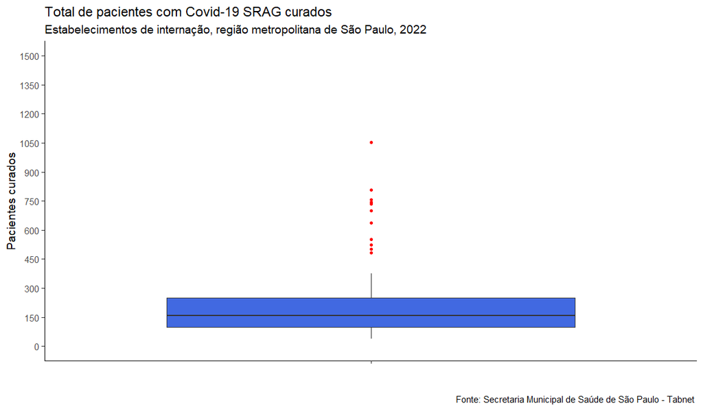

#### Pesquisa de *outliers*

```
##  [1]  701  502 1052  808  756  736  744  524  484  553  636
```

| estab_inter | cura | taxa_ob |
| --- | --- | --- |
| 2077574 CONJUNTO HOSPITALAR DO MANDAQUI SAO PAULO | 701 | 0.0672976 |
| 2089238 HOSP ALVORADA | 502 | 0.0429104 |
| 2078325 HOSP MUN INFANTIL MENINO JESUS | 1052 | 0.0051903 |
| 5718368 HOSP MUN M BOI MIRIM | 808 | 0.0687711 |
| 2080583 HOSP MUN TIDE SETUBAL | 756 | 0.2809991 |
| 2688603 HOSP STA CATARINA | 736 | 0.0314850 |
| 2077671 HOSPITAL GERAL DO GRAJAU PROF LIBER JOHN ALPHONSE DI DIO SP | 744 | 0.0444712 |
| 2088517 HOSPITAL INFANTIL CANDIDO FONTOURA SAO PAULO | 524 | 0.0161290 |
| 2058391 HOSPITAL ISRAELITA ALBERT EINSTEIN | 484 | 0.0643185 |
| 7174721 HOSPITAL SANCTA MAGGIORE PARAISO | 553 | 0.2541087 |
| 3824802 SAO LUIZ UNIDADE MORUMBI | 636 | 0.0209268 |

Observa-se a presença de 11 estabelecimentos (15.94%) que registraram um número absoluto de pacientes curados acima do padrão geral (*outliers*) em 2022.

### *Boxplot* do número absoluto de óbitos

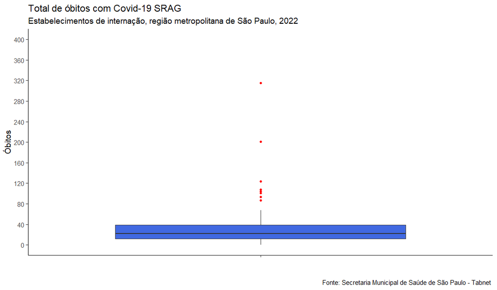

#### Presença de *outliers*

```
## [1] 101 315  87 108 124  93 201 104
```

| estab_inter | obito | taxa_ob |
| --- | --- | --- |
| 2078015 HC DA FMUSP HOSPITAL DAS CLINICAS SAO PAULO | 101 | 0.2144374 |
| 2080583 HOSP MUN TIDE SETUBAL | 315 | 0.2809991 |
| 2077604 HOSP PRESIDENTE | 87 | 0.3270677 |
| 0102105 HOSPITAL MUNICIPAL BRASILANDIA | 108 | 0.4408163 |
| 0161438 HOSPITAL MUNICIPAL GUARAPIRANGA | 124 | 0.3263158 |
| 9554157 HOSPITAL SALVALUS | 93 | 0.3009709 |
| 7174721 HOSPITAL SANCTA MAGGIORE PARAISO | 201 | 0.2541087 |
| 7676484 HOSPITAL SANTA CLARA | 104 | 0.3291139 |

Observa-se a presença de 8 estabelecimentos (11.59%) que registraram um número absoluto de óbitos acima do padrão geral (*outliers*)em 2022.

### *Boxplot* do total de internações

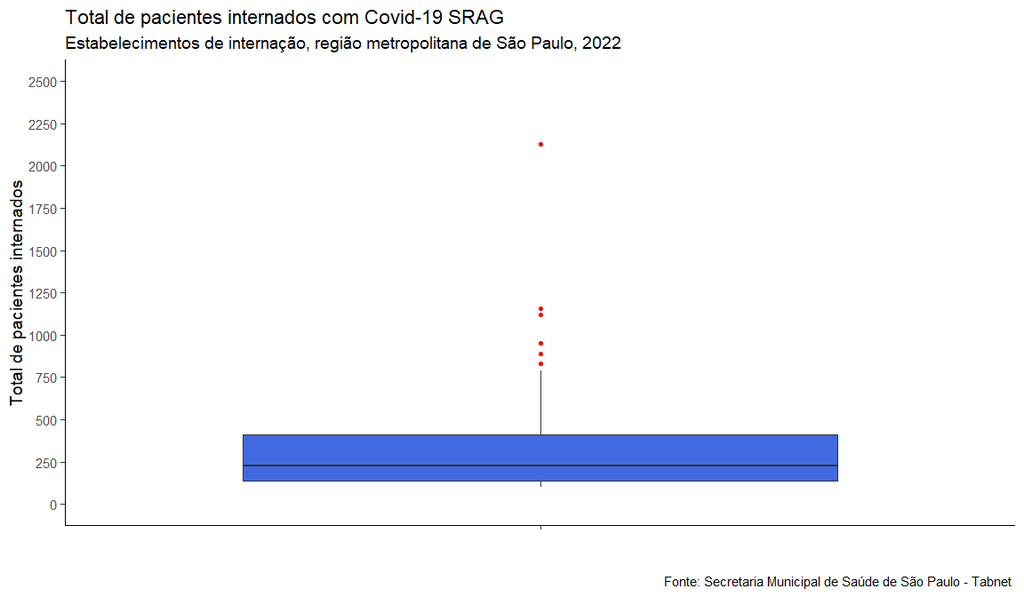

#### Presença de *outliers*

```
## [1]  951 1156  887 1121 2128  832
```

| estab_inter | total | taxa_ob |
| --- | --- | --- |
| 2077574 CONJUNTO HOSPITALAR DO MANDAQUI SAO PAULO | 951 | 0.0672976 |
| 2078325 HOSP MUN INFANTIL MENINO JESUS | 1156 | 0.0051903 |
| 5718368 HOSP MUN M BOI MIRIM | 887 | 0.0687711 |
| 2080583 HOSP MUN TIDE SETUBAL | 1121 | 0.2809991 |
| 2688603 HOSP STA CATARINA | 2128 | 0.0314850 |
| 2077671 HOSPITAL GERAL DO GRAJAU PROF LIBER JOHN ALPHONSE DI DIO SP | 832 | 0.0444712 |

Observa-se a presença de 6 estabelecimentos (8.7%) que registraram um número total de internações acima do padrão geral (*outliers*) em 2022.

## Padronização dos dados 2022

A utilização de variáveis com medidas e ou escalas diferentes podem distorcer a estrutura do *cluster*. Variáveis com maior dispersão têm maior peso para o cálculo das medidas de distância do que as demais.

A padronização dos dados faz com que seja atribuído o mesmo peso para cada variável. Neste estudo foi utilizada a transformação de cada variável em escore padrão (*Z score*). O método Z score padroniza cada variável de modo a apresentar uma média zero(0)e desvio padrão um (1):

$$Z = \frac{(x - média)}{desvio \ padrão}$$

```
##             cura      obito      total     taxa_ob
## [1,] -0.57146576 -0.4031959 -0.6168145  0.05090752
## [2,]  2.13908154  0.5660882  1.8175896 -0.53312024
## [3,]  0.45872536  1.3291416  0.3820687  0.98006349
## [4,] -0.41579244 -0.1969652 -0.3267197 -0.03859378
## [5,] -0.05408089 -0.5063112 -0.2908317 -0.72354980
## [6,]  1.22793473 -0.2794575  0.5764622 -0.78391722
```

# Modelagem estatística

> A partir do conceito filosófico de verissimilitude (MEEHL, apud (CHIN, 2010), os modelos perfeitos inexistem e variam no grau em que se assemelham à realidade que se propõem representar. Isto pode ser analisado sob duas perspectivas: a incompletude (*incompleteness*), que trata do quão bem as complexidades do mundo real são representadas pelo modelo, e a inexatidão (*falseness*), que explora como as contradições entre o modelo e o mundo real são adequadamente expressas (CHIN, 2010). Cabe, pois, ao pesquisador, segundo essa concepção, não questionar se o modelo é verídico, mas como ele é autêntico e em que extensão ele se aproxima da realidade (ROZEBOOM, 2005).

> Antonio Sergio da Silva (SILVA, 2014)

## Método *K-means*

O algoritmo *K-means* é o algoritmo de agrupamento particional mais utilizado baseado no critério da soma dos quadrados (KASSAMBARA, 2017; MACQUEEN, 1967). Trata-se de um algoritmo simples, fácil de implementação e implementado em quase todos os *softwares* de mineração de dados. Ademais, é muito versátil, considerando os aspectos inicialização, distância, função, critério de finalização.

À guisa de exemplo, considere uma classificação de imagens de animais. Uma questão importante poderia ser a imagem de um cão. Qualquer imagem que se pareça com um cão ou partes de um cão, será classificado neste *cluster*. Imagens de peixes e aves ficarão distantes desta classificação e aparecerão em outros *clusters*.

## Determinação do número de *clusters*

O método *k-means* é um procedimento não hierárquico para agrupar indivíduos, cujo número inicial de *clusters* é definido pelo pesquisador (FÁVERO; BELFIORE, 2017; KASSAMBARA, 2017).

A análise visual a partir de um gráfico de linhas de duas dimensões: os *K Clusters* (*Number of clusters k*) e a Soma dos Quadrados dos Erros de Predição (*Total Within Sum of Square - SSE*) sugere um número inicial de *clusters* para ser usado. O SSE resulta na variância e desvio padrão (inércia) dos dados da base utilizada. Desta forma pode-se visualizar o valor de quão próximo os dados estão uns dos outros. Quanto menor for o número de *clusters*, maior será o valor dessa inércia (KASSAMBARA, 2017).

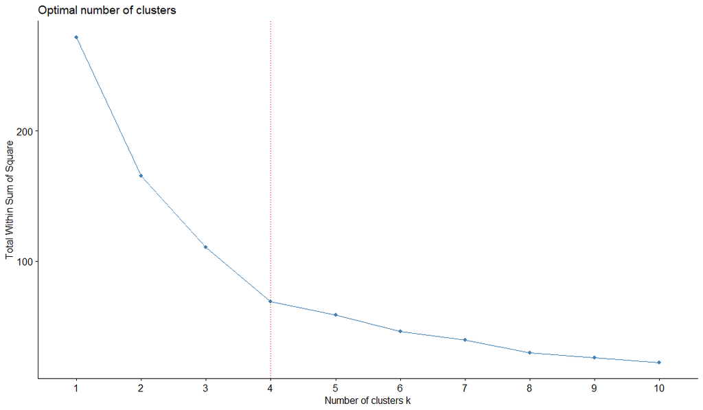

Sendo assim, a quantidade de três a quatro *clusters* parece ser um número bem interessante para se aplicar nesse conjunto de dados.

## Visualização gráfica dos *clusters*

O algoritmo para determinar a alocação das observações em cada conglomerado é denominado *nearest centroid sorting*. O *K-means* usa a distância euclidiana como critério de distância para formar os grupos.

A função `fviz_cluster()` do pacote `fatoextra` pode ser usada para visualizar facilmente os *clusters k-means*. No gráfico resultante, as observações são representadas por pontos, usando análise de componentes principais (PCA) quando o número de variáveis x<sub>ij</sub>for maior do que 2 (KASSAMBARA, 2017).

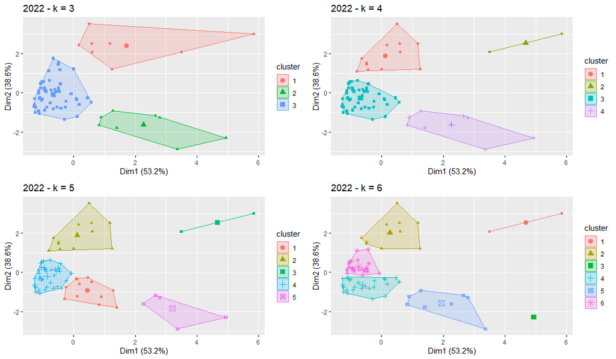

Considerando-se a formação com k = 4 grupos (*clusters*), pode-se perceber que os grupos formados apresentam homogeneidade interna (variabilidade dentro dos grupos), com cada estabelecimento de internação apresentando maior proximidade com outros estabelecimentos do mesmo grupo, do que com estabelecimentos de internação de outros grupos (variabilidade entre os grupos).

## Agrupar *cluster* e base

|  | estab_inter | cura | obito | obito_outros | ignorado | sem_info | total | taxa_ob | evolucao22.k4.cluster |
| --- | --- | --- | --- | --- | --- | --- | --- | --- | --- |
| 3 | 2078015 HC DA FMUSP HOSPITAL DAS CLINICAS SAO PAULO | 334 | 101 | 14 | 5 | 17 | 471 | 0.2144374 | 1 |
| 8 | 2058502 HOSP DO SERV PUB EST FCO MORATO DE OLIVEIRA SAO PAULO | 179 | 58 | 7 | 6 | 6 | 256 | 0.2265625 | 1 |
| 17 | 2080788 HOSP MUN V NHOCUNE ALEXANDRE ZAIO | 68 | 50 | 0 | 9 | 108 | 235 | 0.2127660 | 1 |
| 21 | 2077604 HOSP PRESIDENTE | 90 | 87 | 1 | 1 | 87 | 266 | 0.3270677 | 1 |
| 40 | 2079240 HOSPITAL GERAL JESUS TEIXEIRA DA COSTA GUAIANASES SAO PAULO | 80 | 29 | 0 | 1 | 19 | 129 | 0.2248062 | 1 |
| 46 | 0102105 HOSPITAL MUNICIPAL BRASILANDIA | 112 | 108 | 0 | 4 | 21 | 245 | 0.4408163 | 1 |
| 47 | 0161438 HOSPITAL MUNICIPAL GUARAPIRANGA | 248 | 124 | 0 | 4 | 4 | 380 | 0.3263158 | 1 |
| 52 | 9554157 HOSPITAL SALVALUS | 210 | 93 | 0 | 0 | 6 | 309 | 0.3009709 | 1 |
| 53 | 7174691 HOSPITAL SANCTA MAGGIORE ALTO DA MOOCA | 83 | 37 | 1 | 0 | 4 | 125 | 0.2960000 | 1 |
| 57 | 7357079 HOSPITAL SANCTA MAGGIORE PINHEIROS | 108 | 43 | 1 | 0 | 8 | 160 | 0.2687500 | 1 |
| 58 | 7676484 HOSPITAL SANTA CLARA | 144 | 104 | 0 | 2 | 66 | 316 | 0.3291139 | 1 |
| 63 | 2077485 HOSPITAL SAO PAULO HOSPITAL DE ENSINO DA UNIFESP SAO PAULO | 98 | 44 | 19 | 3 | 9 | 173 | 0.2543353 | 1 |
| 16 | 2080583 HOSP MUN TIDE SETUBAL | 756 | 315 | 1 | 10 | 39 | 1121 | 0.2809991 | 2 |
| 56 | 7174721 HOSPITAL SANCTA MAGGIORE PARAISO | 553 | 201 | 1 | 1 | 35 | 791 | 0.2541087 | 2 |
| 1 | 2077531 A C CAMARGO CANCER CENTER | 109 | 17 | 9 | 0 | 2 | 137 | 0.1240876 | 3 |
| 4 | 2079089 HOSP 9 DE JULHO | 143 | 27 | 0 | 0 | 64 | 234 | 0.1153846 | 3 |
| 5 | 2082314 HOSP ALBERT SABIN | 222 | 12 | 1 | 0 | 11 | 246 | 0.0487805 | 3 |
| 7 | 2078481 HOSP AVICCENA | 108 | 2 | 5 | 2 | 49 | 166 | 0.0120482 | 3 |
| 9 | 2078589 HOSP MAT STA MARIA-CRUZ AZUL | 38 | 37 | 1 | 0 | 695 | 771 | 0.0479896 | 3 |
| 10 | 5420938 HOSP MUN CARMEN PRUDENTE | 107 | 17 | 0 | 0 | 3 | 127 | 0.1338583 | 3 |
| 11 | 2084139 HOSP MUN DR BENEDICTO MONTENEGRO | 50 | 19 | 0 | 0 | 56 | 125 | 0.1520000 | 3 |
| 12 | 7711980 HOSP MUN GILSON DE CASSIA MARQUES DE CARVALHO | 169 | 29 | 0 | 1 | 13 | 212 | 0.1367925 | 3 |
| 15 | 2077639 HOSP MUN PROF DR WALDOMIRO DE PAULA | 90 | 28 | 3 | 14 | 30 | 165 | 0.1696970 | 3 |
| 18 | 3212130 HOSP MUN VER JOSE STOROPOLLI | 162 | 29 | 0 | 39 | 3 | 233 | 0.1244635 | 3 |
| 19 | 2089599 HOSP NSRA DE LOURDES | 77 | 13 | 0 | 0 | 101 | 191 | 0.0680628 | 3 |
| 20 | 2084376 HOSP PAULISTANO | 52 | 8 | 4 | 0 | 54 | 118 | 0.0677966 | 3 |
| 22 | 2080818 HOSP SAMARITANO | 215 | 25 | 0 | 0 | 90 | 330 | 0.0757576 | 3 |
| 23 | 2076896 HOSP SAO LUIZ GONZAGA | 273 | 16 | 0 | 4 | 2 | 295 | 0.0542373 | 3 |
| 24 | 2688611 HOSP SAO LUIZUNIDADE I | 199 | 9 | 2 | 3 | 24 | 237 | 0.0379747 | 3 |
| 25 | 2079127 HOSP SIRIO LIBANES | 240 | 13 | 3 | 1 | 27 | 284 | 0.0457746 | 3 |
| 27 | 2077477 HOSP STA MARCELINA SAO PAULO | 375 | 39 | 20 | 0 | 16 | 450 | 0.0866667 | 3 |
| 28 | 2077507 HOSPITAL BANDEIRANTES | 86 | 10 | 3 | 1 | 37 | 137 | 0.0729927 | 3 |
| 29 | 3309959 HOSPITAL BOSQUE DA SAUDE | 118 | 17 | 0 | 1 | 10 | 146 | 0.1164384 | 3 |
| 30 | 2080575 HOSPITAL BP | 294 | 32 | 4 | 0 | 8 | 338 | 0.0946746 | 3 |
| 31 | 2091801 HOSPITAL CENTRAL DE GUAIANASES | 103 | 3 | 0 | 0 | 3 | 109 | 0.0275229 | 3 |
| 32 | 2080168 HOSPITAL DA CRIANCA | 210 | 1 | 0 | 0 | 265 | 476 | 0.0021008 | 3 |
| 33 | 2081288 HOSPITAL DO CORACAO | 70 | 13 | 3 | 0 | 25 | 111 | 0.1171171 | 3 |
| 34 | 9255826 HOSPITAL E MATERNIDADE GUARULHOS | 90 | 3 | 1 | 0 | 6 | 100 | 0.0300000 | 3 |
| 35 | 2091585 HOSPITAL ESTADUAL DE SAPOPEMBA SAO PAULO | 60 | 22 | 4 | 0 | 49 | 135 | 0.1629630 | 3 |
| 36 | 2077426 HOSPITAL ESTADUAL DE VILA ALPINA ORG SOCIAL SECONCI SAO PAUL | 184 | 38 | 2 | 0 | 269 | 493 | 0.0770791 | 3 |
| 37 | 2066092 HOSPITAL GERAL DE PEDREIRA | 157 | 25 | 1 | 0 | 13 | 196 | 0.1275510 | 3 |
| 38 | 2077493 HOSPITAL GERAL DE SAO MATEUS SAO PAULO | 134 | 22 | 1 | 0 | 21 | 178 | 0.1235955 | 3 |
| 41 | 2084333 HOSPITAL IGESP | 171 | 20 | 11 | 0 | 1 | 203 | 0.0985222 | 3 |
| 44 | 6283993 HOSPITAL LEFORTE | 85 | 4 | 0 | 1 | 15 | 105 | 0.0380952 | 3 |
| 45 | 0102075 HOSPITAL MUNICIPAL BELA VISTA | 75 | 18 | 1 | 1 | 13 | 108 | 0.1666667 | 3 |
| 48 | 2089777 HOSPITAL NIPO BRASILEIRO | 174 | 12 | 1 | 1 | 5 | 193 | 0.0621762 | 3 |
| 49 | 2082330 HOSPITAL NOSSA SENHORA DE FATIMA | 166 | 4 | 0 | 0 | 1 | 171 | 0.0233918 | 3 |
| 50 | 2076950 HOSPITAL OSWALDO CRUZ | 341 | 42 | 13 | 0 | 13 | 409 | 0.1026895 | 3 |
| 51 | 2091313 HOSPITAL REGIONAL SUL SAO PAULO | 99 | 18 | 3 | 0 | 25 | 145 | 0.1241379 | 3 |
| 54 | 9131434 HOSPITAL SANCTA MAGGIORE HIGIENOPOLIS | 121 | 9 | 0 | 0 | 1 | 131 | 0.0687023 | 3 |
| 55 | 7174705 HOSPITAL SANCTA MAGGIORE ITAIM | 89 | 11 | 1 | 0 | 5 | 106 | 0.1037736 | 3 |
| 59 | 2079445 HOSPITAL SANTA ISABEL | 101 | 10 | 4 | 0 | 7 | 122 | 0.0819672 | 3 |
| 60 | 2688565 HOSPITAL SAO CAMILO POMPEIA | 74 | 16 | 0 | 0 | 32 | 122 | 0.1311475 | 3 |
| 61 | 3039420 HOSPITAL SAO CAMILO SANTANA | 185 | 27 | 3 | 3 | 9 | 227 | 0.1189427 | 3 |
| 62 | 9194258 HOSPITAL SAO LUIZ SAO CAETANO | 144 | 0 | 0 | 0 | 2 | 146 | 0.0000000 | 3 |
| 64 | 5590450 HOSPITAL VILLA LOBOS | 168 | 7 | 0 | 0 | 5 | 180 | 0.0388889 | 3 |
| 65 | 6668143 HOSPITAL VITORIA | 250 | 34 | 0 | 0 | 12 | 296 | 0.1148649 | 3 |
| 66 | 2688689 SANTA CASA DE SAO PAULO HOSPITAL CENTRAL SAO PAULO | 154 | 35 | 22 | 2 | 14 | 227 | 0.1541850 | 3 |
| 68 | 7479387 UPA III NOVA CAMPO LIMPO | 237 | 12 | 0 | 0 | 340 | 589 | 0.0203735 | 3 |
| 69 | 4050169 UPA PERUS DR LUIZ ANTONIO DE ABREU SAMPAIO DORIA | 114 | 0 | 3 | 0 | 0 | 117 | 0.0000000 | 3 |
| 2 | 2077574 CONJUNTO HOSPITALAR DO MANDAQUI SAO PAULO | 701 | 64 | 0 | 103 | 83 | 951 | 0.0672976 | 4 |
| 6 | 2089238 HOSP ALVORADA | 502 | 23 | 2 | 0 | 9 | 536 | 0.0429104 | 4 |
| 13 | 2078325 HOSP MUN INFANTIL MENINO JESUS | 1052 | 6 | 0 | 2 | 96 | 1156 | 0.0051903 | 4 |
| 14 | 5718368 HOSP MUN M BOI MIRIM | 808 | 61 | 0 | 1 | 17 | 887 | 0.0687711 | 4 |
| 26 | 2688603 HOSP STA CATARINA | 736 | 67 | 3 | 996 | 326 | 2128 | 0.0314850 | 4 |
| 39 | 2077671 HOSPITAL GERAL DO GRAJAU PROF LIBER JOHN ALPHONSE DI DIO SP | 744 | 37 | 1 | 0 | 50 | 832 | 0.0444712 | 4 |
| 42 | 2088517 HOSPITAL INFANTIL CANDIDO FONTOURA SAO PAULO | 524 | 9 | 0 | 4 | 21 | 558 | 0.0161290 | 4 |
| 43 | 2058391 HOSPITAL ISRAELITA ALBERT EINSTEIN | 484 | 42 | 7 | 67 | 53 | 653 | 0.0643185 | 4 |
| 67 | 3824802 SAO LUIZ UNIDADE MORUMBI | 636 | 14 | 2 | 3 | 14 | 669 | 0.0209268 | 4 |

## Resumo do modelo 2022

### Média aritmética

| evolucao22.k4$cluster | cura | obito | total | taxa_ob |
| --- | --- | --- | --- | --- |
| 1 | 146.17 | 73.17 | 255.42 | 0.29 |
| 2 | 654.50 | 258.00 | 956.00 | 0.27 |
| 3 | 149.63 | 17.50 | 224.72 | 0.08 |
| 4 | 687.44 | 35.89 | 930.00 | 0.04 |

### Desvio padrão

| evolucao22.k4$cluster | cura | obito | total | taxa_ob |
| --- | --- | --- | --- | --- |
| 1 | 81.68 | 32.88 | 103.60 | 0.07 |
| 2 | 143.54 | 80.61 | 233.35 | 0.02 |
| 3 | 77.06 | 11.48 | 141.84 | 0.05 |
| 4 | 179.69 | 24.21 | 492.02 | 0.02 |

### Coeficiente de variação

| evolucao22.k4$cluster | cura | obito | total | taxa_ob |
| --- | --- | --- | --- | --- |
| 1 | 55.88 | 44.94 | 40.56 | 23.29 |
| 2 | 21.93 | 31.24 | 24.41 | 7.11 |
| 3 | 51.50 | 65.63 | 63.12 | 56.83 |
| 4 | 26.14 | 67.46 | 52.91 | 58.46 |

## Validação interna do agrupamento

A validação de agrupamento consiste em projetar o procedimento de avaliação da qualidade dos resultados do algoritmo de agrupamento.

Isso é importante para evitar encontrar padrões em dados aleatórios, bem como na situação em que se deseja a comparação entre dois algoritmos de agrupamento (KASSAMBARA, 2017).

O processo de validação interna usa as informações internas do processo do agrupamento para avaliar a qualidade de uma estrutura de agrupamento, aquém de informações externas. O processo é capaz de estimar o número de **clusters** e o algoritmo de agrupamento apropriado sem nenhum dado externo (KASSAMBARA, 2017).

Medidas internas usam informações intrínsecas nos dados para avaliar a qualidade do agrupamento (KASSAMBARA, 2017).

As medidas internas incluem a conectividade, o coeficiente de silhueta e o índice de Dunn.

### Conectividade

A conectividade corresponde à medida em que os itens são colocados no mesmo *cluster* que seus vizinhos mais próximos no espaço de dados. A conectividade tem um valor entre 0 e infinito e deve ser minimizada (KASSAMBARA, 2017).

### Coeficiente de silhueta

O coeficiente de silhueta (S_i) mede a semelhança de um indivíduo y<sub>i</sub> com os outros indivíduos em seu próprio *cluster* versus os do *cluster* vizinho (KASSAMBARA, 2017).

Os valores de S_i variam de -1 a +1:

- Um valor de S_i próximo a 1 indica que o indivíduo está bem agrupado. Isto é, o indivíduo y<sub>i</sub> é semelhante aos outros índivíduos em seu grupo (KASSAMBARA, 2017).
- Um valor de S_i próximo a -1 indica que o indivíduo está mal agrupado e que a atribuição a algum outro agrupamento provavelmente melhoraria os resultados gerais (KASSAMBARA, 2017).

```
##   cluster size ave.sil.width
## 1       1   46          0.60
## 2       2   12          0.42
## 3       3    2          0.42
## 4       4    9          0.35
```

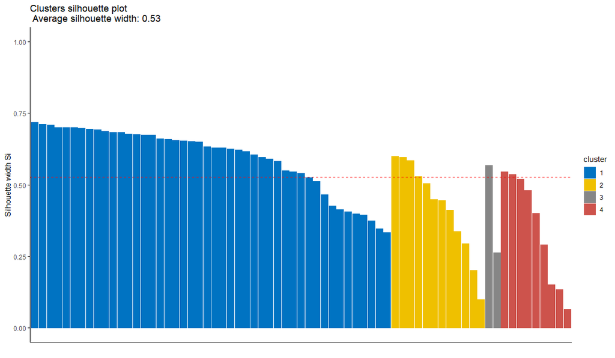

### Coeficientes de silhueta para cada indívíduo y<sub>i</sub>

Abaixo segue a relação dos 10 estabelecimentos (y<sub>i</sub>)com os maiores coeficientes S-i

```
##    cluster neighbor sil_width
## 48       1        2 0.7179231
## 54       1        2 0.7117812
## 64       1        2 0.7089277
## 28       1        2 0.7010070
## 19       1        2 0.6999950
## 24       1        2 0.6996870
## 59       1        2 0.6987361
## 5        1        2 0.6944797
## 49       1        2 0.6925218
## 41       1        2 0.6866928
```

### Indivíduos com Si negativo

Não se observa estabelecimentos com S_i negativos.

```
## [1] cluster   neighbor  sil_width
## <0 linhas> (ou row.names de comprimento 0)
```

Isso significa que todos os indivíduos estão alocados corretamente nos *cluster* gerados.

### Índice de Dun

O índice de Dunn identifica *clusters* densos e bem separados. É definida como a razão entre as distâncias mínimas entre os clusters e a distância máxima entre os clusters.

```
## [1] 0.01072871
```

O índice de Dunn tem um valor entre zero e infinito e deve ser maximizado. As pontuações de Dunn com alto valor são mais desejáveis. Nesta análise o valor é muito baixo, sugerindo que não é um bom agrupamento.

## Avaliação simultânea de algoritmos de agrupamento

O pacote `R clValid` (BROCK *et al.*, 2008) compara simultaneamente vários algoritmos de agrupamento em uma única chamada de função para identificar a melhor abordagem de agrupamento e o número ideal de agrupamentos (KASSAMBARA, 2017).

```
##
## Clustering Methods:
##  hierarchical kmeans pam
##
## Cluster sizes:
##  2 3 4
##
## Validation Measures:
##                                  2       3       4
##
## hierarchical Connectivity   3.0540  7.5786 12.8373
##              Dunn           0.4229  0.3546  0.1613
##              Silhouette     0.6256  0.6237  0.5198
## kmeans       Connectivity  13.4484  9.9944 12.8373
##              Dunn           0.0810  0.1613  0.1613
##              Silhouette     0.5784  0.5524  0.5198
## pam          Connectivity   9.1528 16.0440 30.0373
##              Dunn           0.1148  0.0643  0.0172
##              Silhouette     0.5565  0.5319  0.3019
##
## Optimal Scores:
##
##              Score  Method       Clusters
## Connectivity 3.0540 hierarchical 2
## Dunn         0.4229 hierarchical 2
## Silhouette   0.6256 hierarchical 2
```

Considerando três métodos de agrupamentos (hierárquico, kmeans e pam), os scores de validação interna (conectivdade, índice de Dunn e o coeficiente de silhueta) sugerem o método hierárquico e a formação de dois *clusters* para esse conjunto de dados.

## Medidas de estabilidade

As medidas de estabilidade avaliam a consistência de um resultado de agrupamento comparando-o com os agrupamentos obtidos após a remoção de cada coluna, um de cada vez (KASSAMBARA, 2017).

As medidas de estabilidade de *cluster* incluem:

- A proporção média de não sobreposição (APN);
- A distância média (AD);
- A distância média entre as médias (amc):
- A figura de mérito (FOM).

O APN, AD e amc são todos baseados no cruzamento tabela de classificação do agrupamento original nos dados completos com o agrupamento baseado na remoção de uma coluna (KASSAMBARA, 2017).

O APN mede a proporção média de indivíduos não colocadas no mesmo *cluster* agrupando com base nos dados completos e agrupando com base nos dados com uma única coluna removida (KASSAMBARA, 2017).

O AD mede a distância média entre os indivíduos colocados no mesmo *cluster* em ambos os casos (conjunto de dados completo e remoção de uma coluna) (KASSAMBARA, 2017).

O amc mede a distância média entre os centros dos *clusters* para indivíduos colocadas no mesmo *cluster* em ambos os casos (KASSAMBARA, 2017).

O FOM mede a variação intracluster média da coluna excluída, em que o agrupamento é baseado nas colunas restantes (não excluídas) (KASSAMBARA, 2017).

Os valores de APN, amc e FOM variam de 0 a 1, com valor menor correspondendo a resultados de agrupamento altamente consistentes. AD tem um valor entre 0 e infinito, e valores menores também são preferidos (KASSAMBARA, 2017).

```
##     Score       Method Clusters
## APN  0.03 hierarchical        2
## AD   1.36          pam        4
## ADM  0.19 hierarchical        2
## FOM  0.75          pam        3
```

Observa-se que duas medidas de estabilidade sugerem um número entre 3 e 4 *clusters* para esse conjunto de dados. Nenhuma delas sugeriu o método **k-means** para este cenário.

## Validação externa do agrupamento

Este processo consiste em comparar os resultados de uma análise de *cluster* com um resultado conhecido externamente, como rótulos de classe fornecidos externamente (KASSAMBARA, 2017).

Ele mede até que ponto os rótulos de **cluster** correspondem aos rótulos de classe fornecidos externamente. Usa-se essa abordagem para selecionar o melhor algoritmo de **cluster** para um conjunto de dados específico (KASSAMBARA, 2017).

O índice de Rand (HUBERT; ARABIE, 1985; RAND, 1971) fornece um valor entre 0 e 1, onde 1 significa que os dois resultados de agrupamento correspondem de forma idêntica.

O índice de Rand corrigido fornece uma medida para avaliar a similaridade entre duas partições, ajustadas ao acaso. Seu intervalo é de -1 (sem concordância) a 1 (concordância perfeita) (KASSAMBARA, 2017).

```
## [1] 1
```

```
## [1] 2.220446e-16
```

# Interpretação e validação dos *clusters*

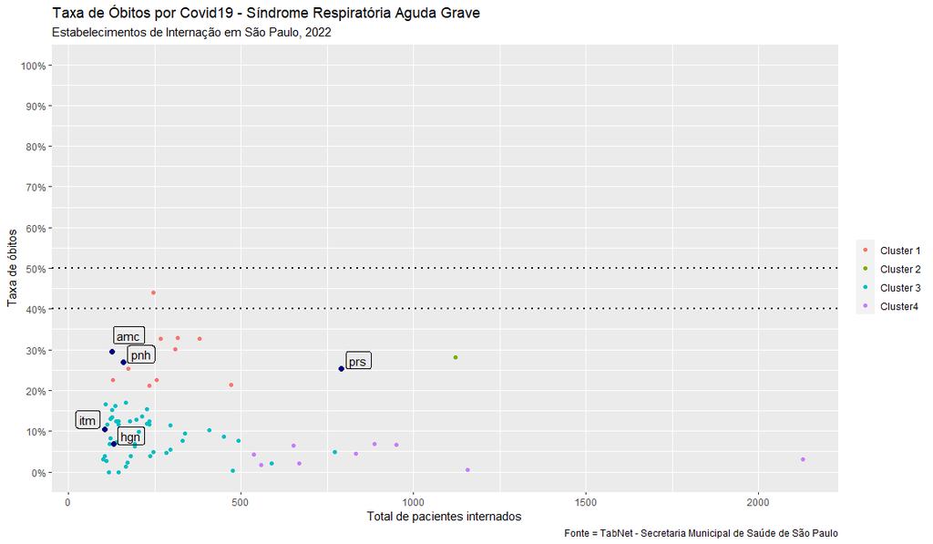

As linhas horizontais pontilhadas em cor preta representam os valores descritos na literatura para a mortalidade geral por SRAG, entre 40 e 50%, para SRAG moderada a grave (VILLAR; BLANCO; KACMAREK, 2016; VILLAR; SULEMANJI; KACMAREK, 2014).